# Overview

Dataset info

| Number of variables | 99 |
| --- | --- |
| Number of observations | 537081 |
| Total Missing (%) | 20.6% |
| Total size in memory | 405.7 MiB |
| Average record size in memory | 792.0 B |

Variables types

| Numeric | 32 |
| --- | --- |
| Categorical | 26 |
| Boolean | 4 |
| Date | 0 |
| Text (Unique) | 0 |
| Rejected | 37 |
| Unsupported | 0 |

Warnings

- `activity_year` has constant value 2018 Rejected
- `lei` has a high cardinality: 836 distinct values Warning
- `state_code` has constant value NY Rejected
- `county_code` is highly skewed (γ1 = -109.41) Skewed
- `census_tract` is highly correlated with `county_code` (ρ = 1) Rejected
- `conforming_loan_limit` has 6979 / 1.3% missing values Missing
- `purchaser_type` has 353713 / 65.9% zeros Zeros
- `open-end_line_of_credit` is highly correlated with `reverse_mortgage` (ρ = 0.98618) Rejected
- `business_or_commercial_purpose` is highly correlated with `open-end_line_of_credit` (ρ = 0.9861) Rejected
- `loan_amount` is highly skewed (γ1 = 104.26) Skewed
- `loan_to_value_ratio` has 144138 / 26.8% missing values Missing
- `loan_to_value_ratio` has a high cardinality: 32994 distinct values Warning
- `interest_rate` has 182122 / 33.9% missing values Missing
- `interest_rate` has a high cardinality: 2341 distinct values Warning
- `rate_spread` has 265405 / 49.4% missing values Missing
- `rate_spread` has a high cardinality: 18393 distinct values Warning
- `total_loan_costs` has 285632 / 53.2% missing values Missing
- `total_loan_costs` has a high cardinality: 152314 distinct values Warning
- `total_points_and_fees` has 520206 / 96.9% missing values Missing
- `total_points_and_fees` has a high cardinality: 673 distinct values Warning
- `origination_charges` has 285854 / 53.2% missing values Missing
- `origination_charges` has a high cardinality: 59913 distinct values Warning
- `discount_points` has 433433 / 80.7% missing values Missing
- `discount_points` has a high cardinality: 40806 distinct values Warning
- `lender_credits` has 431416 / 80.3% missing values Missing
- `lender_credits` has a high cardinality: 32608 distinct values Warning
- `loan_term` has 12214 / 2.3% missing values Missing
- `loan_term` has a high cardinality: 568 distinct values Warning
- `prepayment_penalty_term` has 484006 / 90.1% missing values Missing
- `intro_rate_period` has 383860 / 71.5% missing values Missing
- `intro_rate_period` has a high cardinality: 91 distinct values Warning
- `negative_amortization` is highly correlated with `business_or_commercial_purpose` (ρ = 0.97315) Rejected
- `interest_only_payment` is highly correlated with `negative_amortization` (ρ = 1) Rejected
- `balloon_payment` is highly correlated with `interest_only_payment` (ρ = 1) Rejected
- `other_nonamortizing_features` is highly correlated with `balloon_payment` (ρ = 1) Rejected
- `property_value` has 77294 / 14.4% missing values Missing
- `property_value` has a high cardinality: 1664 distinct values Warning
- `manufactured_home_secured_property_type` is highly correlated with `other_nonamortizing_features` (ρ = 0.98656) Rejected
- `manufactured_home_land_property_interest` is highly correlated with `manufactured_home_secured_property_type` (ρ = 1) Rejected
- `multifamily_affordable_units` has 518232 / 96.5% missing values Missing
- `multifamily_affordable_units` has a high cardinality: 91 distinct values Warning
- `income` has 53414 / 9.9% missing values Missing
- `income` is highly skewed (γ1 = 679.53) Skewed
- `debt_to_income_ratio` has 147171 / 27.4% missing values Missing
- `applicant_credit_score_type` is highly correlated with `manufactured_home_land_property_interest` (ρ = 0.99752) Rejected
- `co-applicant_credit_score_type` is highly correlated with `applicant_credit_score_type` (ρ = 0.99976) Rejected
- `applicant_ethnicity-2` has 525024 / 97.8% missing values Missing
- `applicant_ethnicity-3` has 536813 / 100.0% missing values Missing
- `applicant_ethnicity-4` is highly correlated with `applicant_ethnicity-3` (ρ = 0.91826) Rejected
- `applicant_ethnicity-5` is highly correlated with `applicant_ethnicity-4` (ρ = 1) Rejected
- `co-applicant_ethnicity-2` has 532543 / 99.2% missing values Missing
- `co-applicant_ethnicity-3` has 536991 / 100.0% missing values Missing
- `co-applicant_ethnicity-4` is highly correlated with `co-applicant_ethnicity-3` (ρ = 1) Rejected
- `co-applicant_ethnicity-5` has 537080 / 100.0% missing values Missing
- `applicant_race-2` is highly correlated with `applicant_ethnicity-5` (ρ = 0.99028) Rejected
- `applicant_race-3` has 535974 / 99.8% missing values Missing
- `applicant_race-4` has 536965 / 100.0% missing values Missing
- `applicant_race-5` has 537042 / 100.0% missing values Missing
- `co-applicant_race-1` is highly correlated with `co-applicant_ethnicity-4` (ρ = 1) Rejected
- `co-applicant_race-2` has 528406 / 98.4% missing values Missing
- `co-applicant_race-3` is highly correlated with `applicant_race-5` (ρ = 1) Rejected
- `co-applicant_race-4` is highly correlated with `applicant_race-5` (ρ = 1) Rejected
- `co-applicant_race-5` is highly correlated with `co-applicant_race-4` (ρ = 0.9538) Rejected
- `applicant_race_observed` is highly correlated with `co-applicant_race-5` (ρ = 0.94141) Rejected
- `co-applicant_race_observed` is highly correlated with `co-applicant_race-5` (ρ = 0.94141) Rejected
- `applicant_sex` is highly correlated with `co-applicant_ethnicity-4` (ρ = 1) Rejected
- `co-applicant_sex` is highly correlated with `co-applicant_race_observed` (ρ = 0.93907) Rejected
- `applicant_sex_observed` is highly correlated with `applicant_race_observed` (ρ = 0.97696) Rejected
- `co-applicant_sex_observed` is highly correlated with `co-applicant_sex` (ρ = 0.9419) Rejected
- `applicant_age_above_62` has 49419 / 9.2% missing values Missing
- `co-applicant_age_above_62` has 326524 / 60.8% missing values Missing
- `submission_of_application` is highly correlated with `co-applicant_credit_score_type` (ρ = 0.99872) Rejected
- `initially_payable_to_institution` is highly correlated with `submission_of_application` (ρ = 1) Rejected
- `aus-1` is highly correlated with `initially_payable_to_institution` (ρ = 0.99775) Rejected
- `aus-2` has 511796 / 95.3% missing values Missing
- `aus-3` has 528144 / 98.3% missing values Missing
- `aus-4` is highly correlated with `aus-3` (ρ = 0.95423) Rejected
- `aus-5` is highly correlated with `aus-4` (ρ = 0.96911) Rejected
- `denial_reason-2` has 506868 / 94.4% missing values Missing
- `denial_reason-3` is highly correlated with `applicant_race-5` (ρ = 1) Rejected
- `denial_reason-4` is highly correlated with `applicant_race-3` (ρ = 1) Rejected
- `tract_minority_population_percent` is highly correlated with `co-applicant_ethnicity-4` (ρ = 1) Rejected
- `tract_to_msa_income_percentage` is highly correlated with `co-applicant_ethnicity-4` (ρ = 1) Rejected
- `tract_median_age_of_housing_units` is highly correlated with `co-applicant_ethnicity-4` (ρ = 1) Rejected
- Dataset has 507 duplicate rows Warning

# Variables

activity_year  
Constant

*This variable is constant and should be ignored for analysis*

| Constant value | 2018 |
| --- | --- |

lei  
Categorical

| Distinct count | 836 |
| --- | --- |
| Unique (%) | 0.2% |
| Missing (%) | 0.0% |
| Missing (n) | 0 |

| 7H6GLXDRUGQFU57RNE97 | 41377 |
| --- | --- |
| KB1H1DSPRFMYMCUFXT09 | 38135 |
| 549300FGXN1K3HLB1R50 | 22467 |
| Other values (833) | 435102 |

Toggle details

| Value | Count | Frequency (%) |  |
| --- | --- | --- | --- |
| 7H6GLXDRUGQFU57RNE97 | 41377 | 7.7% |  |
| KB1H1DSPRFMYMCUFXT09 | 38135 | 7.1% |  |
| 549300FGXN1K3HLB1R50 | 22467 | 4.2% |  |
| B4TYDEB6GKMZO031MB27 | 21269 | 4.0% |  |
| E57ODZWZ7FF32TWEFA76 | 20350 | 3.8% |  |
| DRMSV1Q0EKMEXLAU1P80 | 19850 | 3.7% |  |
| WWB2V0FCW3A0EE3ZJN75 | 16481 | 3.1% |  |
| 03D0JEWFDFUS0SEEKG89 | 16343 | 3.0% |  |
| HUX2X73FUCYHUVH1BK78 | 14893 | 2.8% |  |
| 549300KTR1JGH3K6LU06 | 13015 | 2.4% |  |
| Other values (826) | 312901 | 58.3% |  |

derived_msa-md  
Numeric

| Distinct count | 47 |
| --- | --- |
| Unique (%) | 0.0% |
| Missing (%) | 0.0% |
| Missing (n) | 0 |
| Infinite (%) | 0.0% |
| Infinite (n) | 0 |

| Mean | 36588 |
| --- | --- |
| Minimum | 0 |
| Maximum | 99999 |
| Zeros (%) | 0.7% |

Toggle details

**Statistics**

Quantile statistics

| Minimum | 0 |
| --- | --- |
| 5-th percentile | 10580 |
| Q1 | 35004 |
| Median | 35614 |
| Q3 | 35614 |
| 95-th percentile | 99999 |
| Maximum | 99999 |
| Range | 99999 |
| Interquartile range | 610 |

Descriptive statistics

| Standard deviation | 19794 |
| --- | --- |
| Coef of variation | 0.54101 |
| Kurtosis | 4.747 |
| Mean | 36588 |
| MAD | 10558 |
| Skewness | 1.97 |
| Sum | 19650651288 |
| Variance | 391810000 |
| Memory size | 4.1 MiB |

**Histogram**

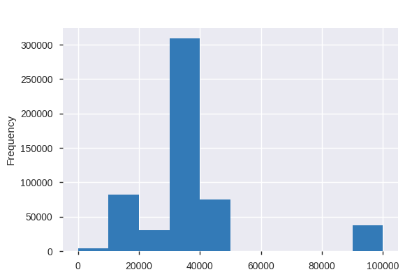

**Common Values**

| Value | Count | Frequency (%) |  |
| --- | --- | --- | --- |
| 35614 | 192503 | 35.8% |  |
| 35004 | 116444 | 21.7% |  |
| 40380 | 41054 | 7.6% |  |
| 15380 | 40210 | 7.5% |  |
| 99999 | 37378 | 7.0% |  |
| 10580 | 35078 | 6.5% |  |
| 45060 | 21451 | 4.0% |  |
| 20524 | 14589 | 2.7% |  |
| 46540 | 8753 | 1.6% |  |
| 13780 | 6946 | 1.3% |  |
| Other values (37) | 22675 | 4.2% |  |

**Extreme Values**

Minimum 5 values

| Value | Count | Frequency (%) |  |
| --- | --- | --- | --- |
| 0 | 3794 | 0.7% |  |
| 10540 | 1 | 0.0% |  |
| 10580 | 35078 | 6.5% |  |
| 10900 | 1 | 0.0% |  |
| 13780 | 6946 | 1.3% |  |

Maximum 5 values

| Value | Count | Frequency (%) |  |
| --- | --- | --- | --- |
| 47220 | 1 | 0.0% |  |
| 47894 | 1 | 0.0% |  |
| 48060 | 3521 | 0.7% |  |
| 48864 | 1 | 0.0% |  |
| 99999 | 37378 | 7.0% |  |

state_code  
Constant

*This variable is constant and should be ignored for analysis*

| Constant value | NY |
| --- | --- |

county_code  
Numeric

| Distinct count | 111 |
| --- | --- |
| Unique (%) | 0.0% |
| Missing (%) | 0.6% |
| Missing (n) | 3181 |
| Infinite (%) | 0.0% |
| Infinite (n) | 0 |

| Mean | 36067 |
| --- | --- |
| Minimum | 4013 |
| Maximum | 55115 |
| Zeros (%) | 0.0% |

Toggle details

**Statistics**

Quantile statistics

| Minimum | 4013 |
| --- | --- |
| 5-th percentile | 36007 |
| Q1 | 36047 |
| Median | 36065 |
| Q3 | 36091 |
| 95-th percentile | 36119 |
| Maximum | 55115 |
| Range | 51102 |
| Interquartile range | 44 |

Descriptive statistics

| Standard deviation | 186.08 |
| --- | --- |
| Coef of variation | 0.0051594 |
| Kurtosis | 17402 |
| Mean | 36067 |
| MAD | 27.173 |
| Skewness | -109.41 |
| Sum | 19256000000 |
| Variance | 34626 |
| Memory size | 4.1 MiB |

**Histogram**

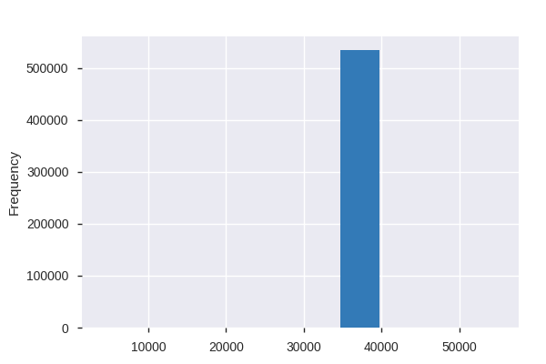

**Common Values**

| Value | Count | Frequency (%) |  |
| --- | --- | --- | --- |
| 36103.0 | 62916 | 11.7% |  |
| 36059.0 | 53554 | 10.0% |  |
| 36081.0 | 45322 | 8.4% |  |
| 36047.0 | 39970 | 7.4% |  |
| 36029.0 | 32997 | 6.1% |  |
| 36119.0 | 30779 | 5.7% |  |
| 36055.0 | 29128 | 5.4% |  |
| 36061.0 | 21061 | 3.9% |  |
| 36085.0 | 17113 | 3.2% |  |
| 36067.0 | 15674 | 2.9% |  |
| Other values (100) | 185386 | 34.5% |  |

**Extreme Values**

Minimum 5 values

| Value | Count | Frequency (%) |  |
| --- | --- | --- | --- |
| 4013.0 | 1 | 0.0% |  |
| 6085.0 | 1 | 0.0% |  |
| 8005.0 | 1 | 0.0% |  |
| 9001.0 | 8 | 0.0% |  |
| 9003.0 | 1 | 0.0% |  |

Maximum 5 values

| Value | Count | Frequency (%) |  |
| --- | --- | --- | --- |
| 48201.0 | 1 | 0.0% |  |
| 51760.0 | 1 | 0.0% |  |
| 53033.0 | 1 | 0.0% |  |
| 54045.0 | 1 | 0.0% |  |
| 55115.0 | 1 | 0.0% |  |

census_tract  
Highly correlated

*This variable is highly correlated with `county_code` and should be ignored for analysis*

| Correlation | 1 |
| --- | --- |

conforming_loan_limit  
Categorical

| Distinct count | 3 |
| --- | --- |
| Unique (%) | 0.0% |
| Missing (%) | 1.3% |
| Missing (n) | 6979 |

| C | 498261 |
| --- | --- |
| NC | 31841 |
| (Missing) | 6979 |

Toggle details

| Value | Count | Frequency (%) |  |
| --- | --- | --- | --- |
| C | 498261 | 92.8% |  |
| NC | 31841 | 5.9% |  |
| (Missing) | 6979 | 1.3% |  |

derived_loan_product_type  
Categorical

| Distinct count | 7 |
| --- | --- |
| Unique (%) | 0.0% |
| Missing (%) | 0.0% |
| Missing (n) | 0 |

| Conventional:First Lien | 344446 |
| --- | --- |
| Conventional:Subordinate Lien | 107546 |
| FHA:First Lien | 66325 |
| Other values (4) | 18764 |

Toggle details

| Value | Count | Frequency (%) |  |
| --- | --- | --- | --- |
| Conventional:First Lien | 344446 | 64.1% |  |
| Conventional:Subordinate Lien | 107546 | 20.0% |  |
| FHA:First Lien | 66325 | 12.3% |  |
| VA:First Lien | 15787 | 2.9% |  |
| FSA/RHS:First Lien | 2764 | 0.5% |  |
| FHA:Subordinate Lien | 212 | 0.0% |  |
| VA:Subordinate Lien | 1 | 0.0% |  |

derived_dwelling_category  
Categorical

| Distinct count | 4 |
| --- | --- |
| Unique (%) | 0.0% |
| Missing (%) | 0.0% |
| Missing (n) | 0 |

| Single Family (1-4 Units):Site-Built | 522134 |
| --- | --- |
| Single Family (1-4 Units):Manufactured | 7968 |
| Multifamily:Site-Built | 6917 |

Toggle details

| Value | Count | Frequency (%) |  |
| --- | --- | --- | --- |
| Single Family (1-4 Units):Site-Built | 522134 | 97.2% |  |
| Single Family (1-4 Units):Manufactured | 7968 | 1.5% |  |
| Multifamily:Site-Built | 6917 | 1.3% |  |
| Multifamily:Manufactured | 62 | 0.0% |  |

derived_ethnicity  
Categorical

| Distinct count | 5 |
| --- | --- |
| Unique (%) | 0.0% |
| Missing (%) | 0.0% |
| Missing (n) | 0 |

| Not Hispanic or Latino | 383706 |
| --- | --- |
| Ethnicity Not Available | 108904 |
| Hispanic or Latino | 35370 |
| Other values (2) | 9101 |

Toggle details

| Value | Count | Frequency (%) |  |
| --- | --- | --- | --- |
| Not Hispanic or Latino | 383706 | 71.4% |  |
| Ethnicity Not Available | 108904 | 20.3% |  |
| Hispanic or Latino | 35370 | 6.6% |  |
| Joint | 8893 | 1.7% |  |
| Free Form Text Only | 208 | 0.0% |  |

derived_race  
Categorical

| Distinct count | 9 |
| --- | --- |
| Unique (%) | 0.0% |
| Missing (%) | 0.0% |
| Missing (n) | 0 |

| White | 338210 |
| --- | --- |
| Race Not Available | 111186 |
| Asian | 41763 |
| Other values (6) | 45922 |

Toggle details

| Value | Count | Frequency (%) |  |
| --- | --- | --- | --- |
| White | 338210 | 63.0% |  |
| Race Not Available | 111186 | 20.7% |  |
| Asian | 41763 | 7.8% |  |
| Black or African American | 33983 | 6.3% |  |
| Joint | 6945 | 1.3% |  |
| Native Hawaiian or Other Pacific Islander | 2197 | 0.4% |  |
| American Indian or Alaska Native | 1746 | 0.3% |  |
| 2 or more minority races | 944 | 0.2% |  |
| Free Form Text Only | 107 | 0.0% |  |

derived_sex  
Categorical

| Distinct count | 4 |
| --- | --- |
| Unique (%) | 0.0% |
| Missing (%) | 0.0% |
| Missing (n) | 0 |

| Joint | 176626 |
| --- | --- |
| Male | 167586 |
| Female | 110503 |

Toggle details

| Value | Count | Frequency (%) |  |
| --- | --- | --- | --- |
| Joint | 176626 | 32.9% |  |
| Male | 167586 | 31.2% |  |
| Female | 110503 | 20.6% |  |
| Sex Not Available | 82366 | 15.3% |  |

action_taken  
Numeric

| Distinct count | 8 |
| --- | --- |
| Unique (%) | 0.0% |
| Missing (%) | 0.0% |
| Missing (n) | 0 |
| Infinite (%) | 0.0% |
| Infinite (n) | 0 |

| Mean | 2.425 |
| --- | --- |
| Minimum | 1 |
| Maximum | 8 |
| Zeros (%) | 0.0% |

Toggle details

**Statistics**

Quantile statistics

| Minimum | 1 |
| --- | --- |
| 5-th percentile | 1 |
| Q1 | 1 |
| Median | 1 |
| Q3 | 3 |
| 95-th percentile | 6 |
| Maximum | 8 |
| Range | 7 |
| Interquartile range | 2 |

Descriptive statistics

| Standard deviation | 1.7557 |
| --- | --- |
| Coef of variation | 0.72399 |
| Kurtosis | -0.49009 |
| Mean | 2.425 |
| MAD | 1.5262 |
| Skewness | 0.89094 |
| Sum | 1302424 |
| Variance | 3.0824 |
| Memory size | 4.1 MiB |

**Histogram**

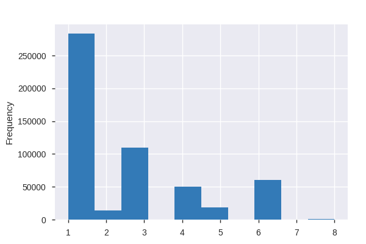

**Common Values**

| Value | Count | Frequency (%) |  |
| --- | --- | --- | --- |
| 1 | 283471 | 52.8% |  |
| 3 | 110023 | 20.5% |  |
| 6 | 60292 | 11.2% |  |
| 4 | 49968 | 9.3% |  |
| 5 | 18634 | 3.5% |  |
| 2 | 13861 | 2.6% |  |
| 8 | 544 | 0.1% |  |
| 7 | 288 | 0.1% |  |

**Extreme Values**

Minimum 5 values

| Value | Count | Frequency (%) |  |
| --- | --- | --- | --- |
| 1 | 283471 | 52.8% |  |
| 2 | 13861 | 2.6% |  |
| 3 | 110023 | 20.5% |  |
| 4 | 49968 | 9.3% |  |
| 5 | 18634 | 3.5% |  |

Maximum 5 values

| Value | Count | Frequency (%) |  |
| --- | --- | --- | --- |
| 4 | 49968 | 9.3% |  |
| 5 | 18634 | 3.5% |  |
| 6 | 60292 | 11.2% |  |
| 7 | 288 | 0.1% |  |
| 8 | 544 | 0.1% |  |

purchaser_type  
Numeric

| Distinct count | 11 |
| --- | --- |
| Unique (%) | 0.0% |
| Missing (%) | 0.0% |
| Missing (n) | 0 |
| Infinite (%) | 0.0% |
| Infinite (n) | 0 |

| Mean | 3.7427 |
| --- | --- |
| Minimum | 0 |
| Maximum | 72 |
| Zeros (%) | 65.9% |

Toggle details

**Statistics**

Quantile statistics

| Minimum | 0 |
| --- | --- |
| 5-th percentile | 0 |
| Q1 | 0 |
| Median | 0 |
| Q3 | 1 |
| 95-th percentile | 9 |
| Maximum | 72 |
| Range | 72 |
| Interquartile range | 1 |

Descriptive statistics

| Standard deviation | 13.806 |
| --- | --- |
| Coef of variation | 3.6888 |
| Kurtosis | 19.382 |
| Mean | 3.7427 |
| MAD | 5.7986 |
| Skewness | 4.5781 |
| Sum | 2010134 |
| Variance | 190.61 |
| Memory size | 4.1 MiB |

**Histogram**

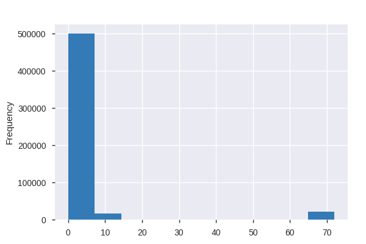

**Common Values**

| Value | Count | Frequency (%) |  |
| --- | --- | --- | --- |
| 0 | 353713 | 65.9% |  |
| 1 | 52081 | 9.7% |  |
| 2 | 36536 | 6.8% |  |
| 3 | 36072 | 6.7% |  |
| 71 | 20420 | 3.8% |  |
| 6 | 19948 | 3.7% |  |
| 9 | 9805 | 1.8% |  |
| 8 | 6132 | 1.1% |  |
| 5 | 1504 | 0.3% |  |
| 72 | 867 | 0.2% |  |

**Extreme Values**

Minimum 5 values

| Value | Count | Frequency (%) |  |
| --- | --- | --- | --- |
| 0 | 353713 | 65.9% |  |
| 1 | 52081 | 9.7% |  |
| 2 | 36536 | 6.8% |  |
| 3 | 36072 | 6.7% |  |
| 4 | 3 | 0.0% |  |

Maximum 5 values

| Value | Count | Frequency (%) |  |
| --- | --- | --- | --- |
| 6 | 19948 | 3.7% |  |
| 8 | 6132 | 1.1% |  |
| 9 | 9805 | 1.8% |  |
| 71 | 20420 | 3.8% |  |
| 72 | 867 | 0.2% |  |

preapproval  
Boolean

| Distinct count | 2 |
| --- | --- |
| Unique (%) | 0.0% |
| Missing (%) | 0.0% |
| Missing (n) | 0 |

| Mean | 1.98 |
| --- | --- |

| 2 | 526324 |
| --- | --- |
| 1 | 10757 |

Toggle details

| Value | Count | Frequency (%) |  |
| --- | --- | --- | --- |
| 2 | 526324 | 98.0% |  |
| 1 | 10757 | 2.0% |  |

loan_type  
Numeric

| Distinct count | 4 |
| --- | --- |
| Unique (%) | 0.0% |
| Missing (%) | 0.0% |
| Missing (n) | 0 |
| Infinite (%) | 0.0% |
| Infinite (n) | 0 |

| Mean | 1.1981 |
| --- | --- |
| Minimum | 1 |
| Maximum | 4 |
| Zeros (%) | 0.0% |

Toggle details

**Statistics**

Quantile statistics

| Minimum | 1 |
| --- | --- |
| 5-th percentile | 1 |
| Q1 | 1 |
| Median | 1 |
| Q3 | 1 |
| 95-th percentile | 2 |
| Maximum | 4 |
| Range | 3 |
| Interquartile range | 0 |

Descriptive statistics

| Standard deviation | 0.49854 |
| --- | --- |
| Coef of variation | 0.4161 |
| Kurtosis | 8.0017 |
| Mean | 1.1981 |
| MAD | 0.33346 |
| Skewness | 2.7643 |
| Sum | 643486 |
| Variance | 0.24854 |
| Memory size | 4.1 MiB |

**Histogram**

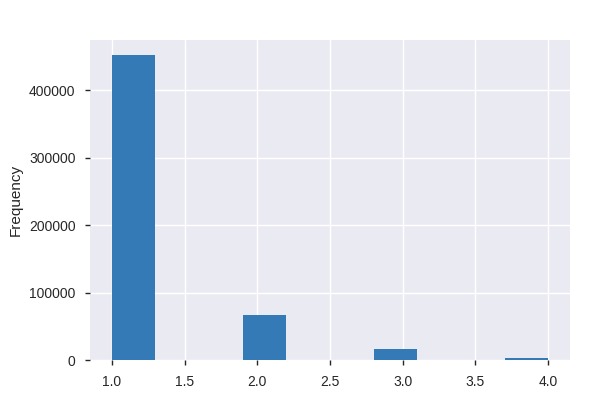

**Common Values**

| Value | Count | Frequency (%) |  |
| --- | --- | --- | --- |
| 1 | 451992 | 84.2% |  |
| 2 | 66537 | 12.4% |  |
| 3 | 15788 | 2.9% |  |
| 4 | 2764 | 0.5% |  |

**Extreme Values**

Minimum 5 values

| Value | Count | Frequency (%) |  |
| --- | --- | --- | --- |
| 1 | 451992 | 84.2% |  |
| 2 | 66537 | 12.4% |  |
| 3 | 15788 | 2.9% |  |
| 4 | 2764 | 0.5% |  |

Maximum 5 values

| Value | Count | Frequency (%) |  |
| --- | --- | --- | --- |
| 1 | 451992 | 84.2% |  |
| 2 | 66537 | 12.4% |  |
| 3 | 15788 | 2.9% |  |
| 4 | 2764 | 0.5% |  |

loan_purpose  
Numeric

| Distinct count | 6 |
| --- | --- |
| Unique (%) | 0.0% |
| Missing (%) | 0.0% |
| Missing (n) | 0 |
| Infinite (%) | 0.0% |
| Infinite (n) | 0 |

| Mean | 11.038 |
| --- | --- |
| Minimum | 1 |
| Maximum | 32 |
| Zeros (%) | 0.0% |

Toggle details

**Statistics**

Quantile statistics

| Minimum | 1 |
| --- | --- |
| 5-th percentile | 1 |
| Q1 | 1 |
| Median | 2 |
| Q3 | 31 |
| 95-th percentile | 32 |
| Maximum | 32 |
| Range | 31 |
| Interquartile range | 30 |

Descriptive statistics

| Standard deviation | 13.861 |
| --- | --- |
| Coef of variation | 1.2558 |
| Kurtosis | -1.3481 |
| Mean | 11.038 |
| MAD | 12.818 |
| Skewness | 0.79373 |
| Sum | 5928104 |
| Variance | 192.14 |
| Memory size | 4.1 MiB |

**Histogram**

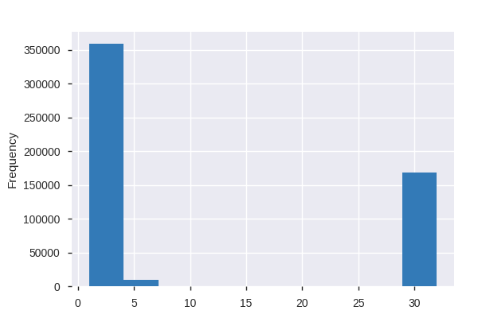

**Common Values**

| Value | Count | Frequency (%) |  |
| --- | --- | --- | --- |
| 1 | 240703 | 44.8% |  |
| 32 | 88965 | 16.6% |  |
| 31 | 79016 | 14.7% |  |
| 2 | 66280 | 12.3% |  |
| 4 | 52120 | 9.7% |  |
| 5 | 9997 | 1.9% |  |

**Extreme Values**

Minimum 5 values

| Value | Count | Frequency (%) |  |
| --- | --- | --- | --- |
| 1 | 240703 | 44.8% |  |
| 2 | 66280 | 12.3% |  |
| 4 | 52120 | 9.7% |  |
| 5 | 9997 | 1.9% |  |
| 31 | 79016 | 14.7% |  |

Maximum 5 values

| Value | Count | Frequency (%) |  |
| --- | --- | --- | --- |
| 2 | 66280 | 12.3% |  |
| 4 | 52120 | 9.7% |  |
| 5 | 9997 | 1.9% |  |
| 31 | 79016 | 14.7% |  |
| 32 | 88965 | 16.6% |  |

lien_status  
Boolean

| Distinct count | 2 |
| --- | --- |
| Unique (%) | 0.0% |
| Missing (%) | 0.0% |
| Missing (n) | 0 |

| Mean | 1.2006 |
| --- | --- |

| 1 | 429322 |
| --- | --- |
| 2 | 107759 |

Toggle details

| Value | Count | Frequency (%) |  |
| --- | --- | --- | --- |
| 1 | 429322 | 79.9% |  |
| 2 | 107759 | 20.1% |  |

reverse_mortgage  
Numeric

| Distinct count | 3 |
| --- | --- |
| Unique (%) | 0.0% |
| Missing (%) | 0.0% |
| Missing (n) | 0 |
| Infinite (%) | 0.0% |
| Infinite (n) | 0 |

| Mean | 33.157 |
| --- | --- |
| Minimum | 1 |
| Maximum | 1111 |
| Zeros (%) | 0.0% |

Toggle details

**Statistics**

Quantile statistics

| Minimum | 1 |
| --- | --- |
| 5-th percentile | 2 |
| Q1 | 2 |
| Median | 2 |
| Q3 | 2 |
| 95-th percentile | 2 |
| Maximum | 1111 |
| Range | 1110 |
| Interquartile range | 0 |

Descriptive statistics

| Standard deviation | 183.27 |
| --- | --- |
| Coef of variation | 5.5275 |
| Kurtosis | 30.616 |
| Mean | 33.157 |
| MAD | 60.575 |
| Skewness | 5.7111 |
| Sum | 17807880 |
| Variance | 33589 |
| Memory size | 4.1 MiB |

**Histogram**

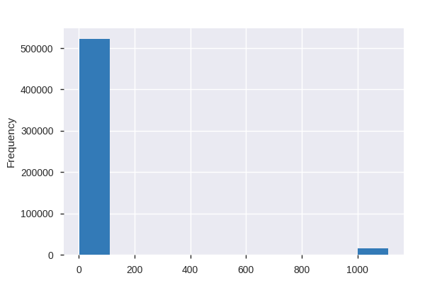

**Common Values**

| Value | Count | Frequency (%) |  |
| --- | --- | --- | --- |
| 2 | 518679 | 96.6% |  |
| 1111 | 15092 | 2.8% |  |
| 1 | 3310 | 0.6% |  |

**Extreme Values**

Minimum 5 values

| Value | Count | Frequency (%) |  |
| --- | --- | --- | --- |
| 1 | 3310 | 0.6% |  |
| 2 | 518679 | 96.6% |  |
| 1111 | 15092 | 2.8% |  |

Maximum 5 values

| Value | Count | Frequency (%) |  |
| --- | --- | --- | --- |
| 1 | 3310 | 0.6% |  |
| 2 | 518679 | 96.6% |  |
| 1111 | 15092 | 2.8% |  |

open-end_line_of_credit  
Highly correlated

*This variable is highly correlated with `reverse_mortgage` and should be ignored for analysis*

| Correlation | 0.98618 |
| --- | --- |

business_or_commercial_purpose  
Highly correlated

*This variable is highly correlated with `open-end_line_of_credit` and should be ignored for analysis*

| Correlation | 0.9861 |
| --- | --- |

loan_amount  
Numeric

| Distinct count | 1282 |
| --- | --- |
| Unique (%) | 0.2% |
| Missing (%) | 0.0% |
| Missing (n) | 0 |
| Infinite (%) | 0.0% |
| Infinite (n) | 0 |

| Mean | 355650 |
| --- | --- |
| Minimum | 5000 |
| Maximum | 500000000 |
| Zeros (%) | 0.0% |

Toggle details

**Statistics**

Quantile statistics

| Minimum | 5000 |
| --- | --- |
| 5-th percentile | 25000 |
| Q1 | 95000 |
| Median | 185000 |
| Q3 | 365000 |
| 95-th percentile | 805000 |
| Maximum | 500000000 |
| Range | 500000000 |
| Interquartile range | 270000 |

Descriptive statistics

| Standard deviation | 2527500 |
| --- | --- |
| Coef of variation | 7.1068 |
| Kurtosis | 14617 |
| Mean | 355650 |
| MAD | 304440 |
| Skewness | 104.26 |
| Sum | 191010000000 |
| Variance | 6388300000000 |
| Memory size | 4.1 MiB |

**Histogram**

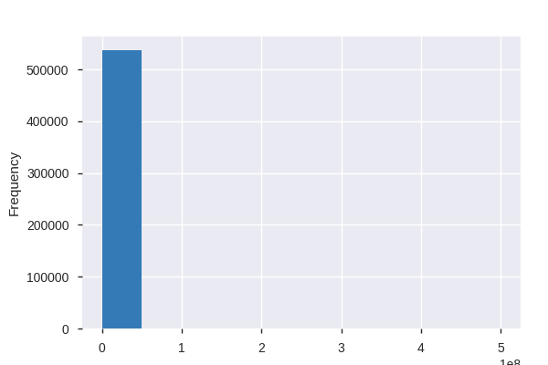

**Common Values**

| Value | Count | Frequency (%) |  |
| --- | --- | --- | --- |
| 105000.0 | 32445 | 6.0% |  |
| 55000.0 | 25274 | 4.7% |  |
| 155000.0 | 16885 | 3.1% |  |
| 25000.0 | 16537 | 3.1% |  |
| 75000.0 | 16499 | 3.1% |  |
| 65000.0 | 15634 | 2.9% |  |
| 125000.0 | 15568 | 2.9% |  |
| 205000.0 | 15554 | 2.9% |  |
| 85000.0 | 14432 | 2.7% |  |
| 35000.0 | 14203 | 2.6% |  |
| Other values (1272) | 354050 | 65.9% |  |

**Extreme Values**

Minimum 5 values

| Value | Count | Frequency (%) |  |
| --- | --- | --- | --- |
| 5000.0 | 4019 | 0.7% |  |
| 15000.0 | 8125 | 1.5% |  |
| 25000.0 | 16537 | 3.1% |  |
| 35000.0 | 14203 | 2.6% |  |
| 45000.0 | 12563 | 2.3% |  |

Maximum 5 values

| Value | Count | Frequency (%) |  |
| --- | --- | --- | --- |
| 381005000.0 | 1 | 0.0% |  |
| 407005000.0 | 1 | 0.0% |  |
| 453685000.0 | 1 | 0.0% |  |
| 470005000.0 | 1 | 0.0% |  |
| 500005000.0 | 1 | 0.0% |  |

loan_to_value_ratio  
Categorical

| Distinct count | 32994 |
| --- | --- |
| Unique (%) | 6.1% |
| Missing (%) | 26.8% |
| Missing (n) | 144138 |

| 80.0 | 43687 |
| --- | --- |
| Exempt | 15533 |
| 96.5 | 15054 |
| Other values (32990) | 318669 |
| (Missing) | 144138 |

Toggle details

| Value | Count | Frequency (%) |  |
| --- | --- | --- | --- |
| 80.0 | 43687 | 8.1% |  |
| Exempt | 15533 | 2.9% |  |
| 96.5 | 15054 | 2.8% |  |
| 95.0 | 14229 | 2.6% |  |
| 90.0 | 12285 | 2.3% |  |
| 75.0 | 11942 | 2.2% |  |
| 85.0 | 8013 | 1.5% |  |
| 100.0 | 6498 | 1.2% |  |
| 70.0 | 5872 | 1.1% |  |
| 97.0 | 4602 | 0.9% |  |
| Other values (32983) | 255228 | 47.5% |  |
| (Missing) | 144138 | 26.8% |  |

interest_rate  
Categorical

| Distinct count | 2341 |
| --- | --- |
| Unique (%) | 0.4% |
| Missing (%) | 33.9% |
| Missing (n) | 182122 |

| 4.75 | 30837 |
| --- | --- |
| 4.5 | 27803 |
| 4.625 | 24299 |
| Other values (2337) | 272020 |
| (Missing) | 182122 |

Toggle details

| Value | Count | Frequency (%) |  |
| --- | --- | --- | --- |
| 4.75 | 30837 | 5.7% |  |
| 4.5 | 27803 | 5.2% |  |
| 4.625 | 24299 | 4.5% |  |
| 4.875 | 23207 | 4.3% |  |
| 4.25 | 18797 | 3.5% |  |
| 4.375 | 17788 | 3.3% |  |
| Exempt | 15526 | 2.9% |  |
| 5.0 | 14395 | 2.7% |  |
| 5.25 | 12606 | 2.3% |  |
| 4.125 | 11609 | 2.2% |  |
| Other values (2330) | 158092 | 29.4% |  |
| (Missing) | 182122 | 33.9% |  |

rate_spread  
Categorical

| Distinct count | 18393 |
| --- | --- |
| Unique (%) | 3.4% |
| Missing (%) | 49.4% |
| Missing (n) | 265405 |

| Exempt | 15432 |
| --- | --- |
| 0.0 | 1171 |
| 4.75 | 543 |
| Other values (18389) | 254530 |
| (Missing) | 265405 |

Toggle details

| Value | Count | Frequency (%) |  |
| --- | --- | --- | --- |
| Exempt | 15432 | 2.9% |  |
| 0.0 | 1171 | 0.2% |  |
| 4.75 | 543 | 0.1% |  |
| -0.23 | 525 | 0.1% |  |
| 0.02 | 491 | 0.1% |  |
| -0.25 | 478 | 0.1% |  |
| 0.27 | 473 | 0.1% |  |
| -0.01 | 457 | 0.1% |  |
| 0.01 | 439 | 0.1% |  |
| 5.0 | 436 | 0.1% |  |
| Other values (18382) | 251231 | 46.8% |  |
| (Missing) | 265405 | 49.4% |  |

hoepa_status  
Numeric

| Distinct count | 3 |
| --- | --- |
| Unique (%) | 0.0% |
| Missing (%) | 0.0% |
| Missing (n) | 0 |
| Infinite (%) | 0.0% |
| Infinite (n) | 0 |

| Mean | 2.428 |
| --- | --- |
| Minimum | 1 |
| Maximum | 3 |
| Zeros (%) | 0.0% |

Toggle details

**Statistics**

Quantile statistics

| Minimum | 1 |
| --- | --- |
| 5-th percentile | 2 |
| Q1 | 2 |
| Median | 2 |
| Q3 | 3 |
| 95-th percentile | 3 |
| Maximum | 3 |
| Range | 2 |
| Interquartile range | 1 |

Descriptive statistics

| Standard deviation | 0.49542 |
| --- | --- |
| Coef of variation | 0.20405 |
| Kurtosis | -1.899 |
| Mean | 2.428 |
| MAD | 0.48998 |
| Skewness | 0.28341 |
| Sum | 1304021 |
| Variance | 0.24544 |
| Memory size | 4.1 MiB |

**Histogram**

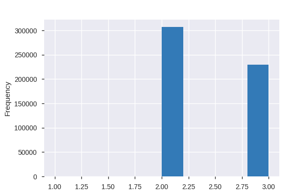

**Common Values**

| Value | Count | Frequency (%) |  |
| --- | --- | --- | --- |
| 2 | 306886 | 57.1% |  |
| 3 | 230027 | 42.8% |  |
| 1 | 168 | 0.0% |  |

**Extreme Values**

Minimum 5 values

| Value | Count | Frequency (%) |  |
| --- | --- | --- | --- |
| 1 | 168 | 0.0% |  |
| 2 | 306886 | 57.1% |  |
| 3 | 230027 | 42.8% |  |

Maximum 5 values

| Value | Count | Frequency (%) |  |
| --- | --- | --- | --- |
| 1 | 168 | 0.0% |  |
| 2 | 306886 | 57.1% |  |
| 3 | 230027 | 42.8% |  |

total_loan_costs  
Categorical

| Distinct count | 152314 |
| --- | --- |
| Unique (%) | 28.4% |
| Missing (%) | 53.2% |
| Missing (n) | 285632 |

| Exempt | 15528 |
| --- | --- |
| 0.0 | 9147 |
| 485.0 | 449 |
| Other values (152310) | 226325 |
| (Missing) | 285632 |

Toggle details

| Value | Count | Frequency (%) |  |
| --- | --- | --- | --- |
| Exempt | 15528 | 2.9% |  |
| 0.0 | 9147 | 1.7% |  |
| 485.0 | 449 | 0.1% |  |
| 15.0 | 401 | 0.1% |  |
| 500.0 | 392 | 0.1% |  |
| 336.0 | 334 | 0.1% |  |
| 400.0 | 296 | 0.1% |  |
| 450.0 | 288 | 0.1% |  |
| 337.0 | 237 | 0.0% |  |
| 535.0 | 174 | 0.0% |  |
| Other values (152303) | 224203 | 41.7% |  |
| (Missing) | 285632 | 53.2% |  |

total_points_and_fees  
Categorical

| Distinct count | 673 |
| --- | --- |
| Unique (%) | 0.1% |
| Missing (%) | 96.9% |
| Missing (n) | 520206 |

| Exempt | 15528 |
| --- | --- |
| 0.0 | 387 |
| 661.5 | 45 |
| Other values (669) | 915 |
| (Missing) | 520206 |

Toggle details

| Value | Count | Frequency (%) |  |
| --- | --- | --- | --- |
| Exempt | 15528 | 2.9% |  |
| 0.0 | 387 | 0.1% |  |
| 661.5 | 45 | 0.0% |  |
| 2900.0 | 43 | 0.0% |  |
| 749.0 | 36 | 0.0% |  |
| 499.0 | 28 | 0.0% |  |
| 195.0 | 22 | 0.0% |  |
| 2399.0 | 17 | 0.0% |  |
| 599.0 | 7 | 0.0% |  |
| 915.43 | 6 | 0.0% |  |
| Other values (662) | 756 | 0.1% |  |
| (Missing) | 520206 | 96.9% |  |

origination_charges  
Categorical

| Distinct count | 59913 |
| --- | --- |
| Unique (%) | 11.2% |
| Missing (%) | 53.2% |
| Missing (n) | 285854 |

| 0.0 | 34100 |
| --- | --- |
| Exempt | 15528 |
| 995.0 | 6175 |
| Other values (59909) | 195424 |
| (Missing) | 285854 |

Toggle details

| Value | Count | Frequency (%) |  |
| --- | --- | --- | --- |
| 0.0 | 34100 | 6.3% |  |
| Exempt | 15528 | 2.9% |  |
| 995.0 | 6175 | 1.1% |  |
| 900.0 | 4126 | 0.8% |  |
| 795.0 | 3287 | 0.6% |  |
| 1290.0 | 2458 | 0.5% |  |
| 1090.0 | 2164 | 0.4% |  |
| 1015.0 | 2111 | 0.4% |  |
| 1082.0 | 2024 | 0.4% |  |
| 1490.0 | 2009 | 0.4% |  |
| Other values (59902) | 177245 | 33.0% |  |
| (Missing) | 285854 | 53.2% |  |

discount_points  
Categorical

| Distinct count | 40806 |
| --- | --- |
| Unique (%) | 7.6% |
| Missing (%) | 80.7% |
| Missing (n) | 433433 |

| Exempt | 15527 |
| --- | --- |
| 750.0 | 257 |
| 1500.0 | 250 |
| Other values (40802) | 87614 |
| (Missing) | 433433 |

Toggle details

| Value | Count | Frequency (%) |  |
| --- | --- | --- | --- |
| Exempt | 15527 | 2.9% |  |
| 750.0 | 257 | 0.0% |  |
| 1500.0 | 250 | 0.0% |  |
| 1000.0 | 223 | 0.0% |  |
| 500.0 | 215 | 0.0% |  |
| 375.0 | 191 | 0.0% |  |
| 2000.0 | 190 | 0.0% |  |
| 3000.0 | 177 | 0.0% |  |
| 2250.0 | 162 | 0.0% |  |
| 2500.0 | 152 | 0.0% |  |
| Other values (40795) | 86304 | 16.1% |  |
| (Missing) | 433433 | 80.7% |  |

lender_credits  
Categorical

| Distinct count | 32608 |
| --- | --- |
| Unique (%) | 6.1% |
| Missing (%) | 80.3% |
| Missing (n) | 431416 |

| Exempt | 15527 |
| --- | --- |
| 500.0 | 2779 |
| 250.0 | 2278 |
| Other values (32604) | 85081 |
| (Missing) | 431416 |

Toggle details

| Value | Count | Frequency (%) |  |
| --- | --- | --- | --- |
| Exempt | 15527 | 2.9% |  |
| 500.0 | 2779 | 0.5% |  |
| 250.0 | 2278 | 0.4% |  |
| 150.0 | 1018 | 0.2% |  |
| 300.0 | 946 | 0.2% |  |
| 10.0 | 912 | 0.2% |  |
| 1000.0 | 896 | 0.2% |  |
| 650.0 | 828 | 0.2% |  |
| 100.0 | 722 | 0.1% |  |
| 50.0 | 699 | 0.1% |  |
| Other values (32597) | 79060 | 14.7% |  |
| (Missing) | 431416 | 80.3% |  |

loan_term  
Categorical

| Distinct count | 568 |
| --- | --- |
| Unique (%) | 0.1% |
| Missing (%) | 2.3% |
| Missing (n) | 12214 |

| 360 | 370060 |
| --- | --- |
| 180 | 40220 |
| 240 | 34446 |
| Other values (564) | 80141 |

Toggle details

| Value | Count | Frequency (%) |  |
| --- | --- | --- | --- |
| 360 | 370060 | 68.9% |  |
| 180 | 40220 | 7.5% |  |
| 240 | 34446 | 6.4% |  |
| 300 | 18290 | 3.4% |  |
| 120 | 17430 | 3.2% |  |
| Exempt | 15525 | 2.9% |  |
| 361 | 10042 | 1.9% |  |
| 60 | 5742 | 1.1% |  |
| 12 | 1844 | 0.3% |  |
| 480 | 1367 | 0.3% |  |
| Other values (557) | 9901 | 1.8% |  |
| (Missing) | 12214 | 2.3% |  |

prepayment_penalty_term  
Categorical

| Distinct count | 17 |
| --- | --- |
| Unique (%) | 0.0% |
| Missing (%) | 90.1% |
| Missing (n) | 484006 |

| 36 | 31295 |
| --- | --- |
| Exempt | 15528 |
| 24 | 4848 |
| Other values (13) | 1404 |
| (Missing) | 484006 |

Toggle details

| Value | Count | Frequency (%) |  |
| --- | --- | --- | --- |
| 36 | 31295 | 5.8% |  |
| Exempt | 15528 | 2.9% |  |
| 24 | 4848 | 0.9% |  |
| 0 | 1086 | 0.2% |  |
| 54 | 225 | 0.0% |  |
| 12 | 47 | 0.0% |  |
| 1 | 13 | 0.0% |  |
| 18 | 10 | 0.0% |  |
| 60 | 8 | 0.0% |  |
| 2 | 8 | 0.0% |  |
| Other values (6) | 7 | 0.0% |  |
| (Missing) | 484006 | 90.1% |  |

intro_rate_period  
Categorical

| Distinct count | 91 |
| --- | --- |
| Unique (%) | 0.0% |
| Missing (%) | 71.5% |
| Missing (n) | 383860 |

| 1 | 87592 |
| --- | --- |
| Exempt | 15526 |
| 60 | 10095 |
| Other values (87) | 40008 |
| (Missing) | 383860 |

Toggle details

| Value | Count | Frequency (%) |  |
| --- | --- | --- | --- |
| 1 | 87592 | 16.3% |  |
| Exempt | 15526 | 2.9% |  |
| 60 | 10095 | 1.9% |  |
| 84 | 9583 | 1.8% |  |
| 6 | 6817 | 1.3% |  |
| 12 | 6684 | 1.2% |  |
| 120 | 6529 | 1.2% |  |
| 180 | 2022 | 0.4% |  |
| 36 | 1624 | 0.3% |  |
| 24 | 1359 | 0.3% |  |
| Other values (80) | 5390 | 1.0% |  |
| (Missing) | 383860 | 71.5% |  |

negative_amortization  
Highly correlated

*This variable is highly correlated with `business_or_commercial_purpose` and should be ignored for analysis*

| Correlation | 0.97315 |
| --- | --- |

interest_only_payment  
Highly correlated

*This variable is highly correlated with `negative_amortization` and should be ignored for analysis*

| Correlation | 1 |
| --- | --- |

balloon_payment  
Highly correlated

*This variable is highly correlated with `interest_only_payment` and should be ignored for analysis*

| Correlation | 1 |
| --- | --- |

other_nonamortizing_features  
Highly correlated

*This variable is highly correlated with `balloon_payment` and should be ignored for analysis*

| Correlation | 1 |
| --- | --- |

property_value  
Categorical

| Distinct count | 1664 |
| --- | --- |
| Unique (%) | 0.3% |
| Missing (%) | 14.4% |
| Missing (n) | 77294 |

| Exempt | 15532 |
| --- | --- |
| 125000 | 10881 |
| 135000 | 10870 |
| Other values (1660) | 422504 |
| (Missing) | 77294 |

Toggle details

| Value | Count | Frequency (%) |  |
| --- | --- | --- | --- |
| Exempt | 15532 | 2.9% |  |
| 125000 | 10881 | 2.0% |  |
| 135000 | 10870 | 2.0% |  |
| 145000 | 10334 | 1.9% |  |
| 155000 | 10127 | 1.9% |  |
| 165000 | 9529 | 1.8% |  |
| 115000 | 8866 | 1.7% |  |
| 175000 | 8820 | 1.6% |  |
| 185000 | 8052 | 1.5% |  |
| 105000 | 7693 | 1.4% |  |
| Other values (1653) | 359083 | 66.9% |  |
| (Missing) | 77294 | 14.4% |  |

construction_method  
Boolean

| Distinct count | 2 |
| --- | --- |
| Unique (%) | 0.0% |
| Missing (%) | 0.0% |
| Missing (n) | 0 |

| Mean | 1.015 |
| --- | --- |

| 1 | 529051 |
| --- | --- |
| 2 | 8030 |

Toggle details

| Value | Count | Frequency (%) |  |
| --- | --- | --- | --- |
| 1 | 529051 | 98.5% |  |
| 2 | 8030 | 1.5% |  |

occupancy_type  
Numeric

| Distinct count | 3 |
| --- | --- |
| Unique (%) | 0.0% |
| Missing (%) | 0.0% |
| Missing (n) | 0 |
| Infinite (%) | 0.0% |
| Infinite (n) | 0 |

| Mean | 1.1746 |
| --- | --- |
| Minimum | 1 |
| Maximum | 3 |
| Zeros (%) | 0.0% |

Toggle details

**Statistics**

Quantile statistics

| Minimum | 1 |
| --- | --- |
| 5-th percentile | 1 |
| Q1 | 1 |
| Median | 1 |
| Q3 | 1 |
| 95-th percentile | 3 |
| Maximum | 3 |
| Range | 2 |
| Interquartile range | 0 |

Descriptive statistics

| Standard deviation | 0.53822 |
| --- | --- |
| Coef of variation | 0.4582 |
| Kurtosis | 6.798 |
| Mean | 1.1746 |
| MAD | 0.31371 |
| Skewness | 2.9129 |
| Sum | 630880 |
| Variance | 0.28968 |
| Memory size | 4.1 MiB |

**Histogram**

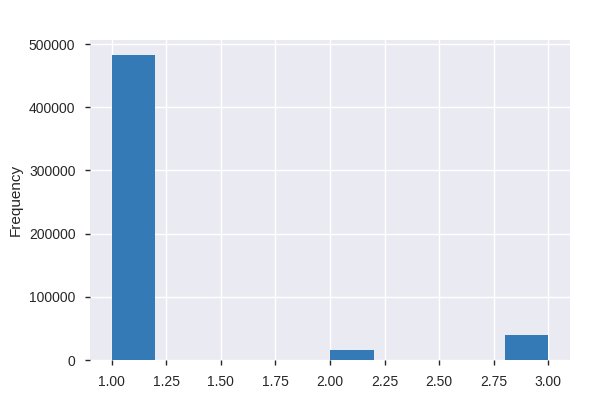

**Common Values**

| Value | Count | Frequency (%) |  |
| --- | --- | --- | --- |
| 1 | 482364 | 89.8% |  |
| 3 | 39082 | 7.3% |  |
| 2 | 15635 | 2.9% |  |

**Extreme Values**

Minimum 5 values

| Value | Count | Frequency (%) |  |
| --- | --- | --- | --- |
| 1 | 482364 | 89.8% |  |
| 2 | 15635 | 2.9% |  |
| 3 | 39082 | 7.3% |  |

Maximum 5 values

| Value | Count | Frequency (%) |  |
| --- | --- | --- | --- |
| 1 | 482364 | 89.8% |  |
| 2 | 15635 | 2.9% |  |
| 3 | 39082 | 7.3% |  |

manufactured_home_secured_property_type  
Highly correlated

*This variable is highly correlated with `other_nonamortizing_features` and should be ignored for analysis*

| Correlation | 0.98656 |
| --- | --- |

manufactured_home_land_property_interest  
Highly correlated

*This variable is highly correlated with `manufactured_home_secured_property_type` and should be ignored for analysis*

| Correlation | 1 |
| --- | --- |

total_units  
Categorical

| Distinct count | 9 |
| --- | --- |
| Unique (%) | 0.0% |
| Missing (%) | 0.0% |
| Missing (n) | 0 |

| 1 | 468247 |
| --- | --- |
| 2 | 48907 |
| 3 | 9244 |
| Other values (6) | 10683 |

Toggle details

| Value | Count | Frequency (%) |  |
| --- | --- | --- | --- |
| 1 | 468247 | 87.2% |  |
| 2 | 48907 | 9.1% |  |
| 3 | 9244 | 1.7% |  |
| 5-24 | 4200 | 0.8% |  |
| 4 | 3704 | 0.7% |  |
| 25-49 | 1255 | 0.2% |  |
| 50-99 | 977 | 0.2% |  |
| >149 | 296 | 0.1% |  |
| 100-149 | 251 | 0.0% |  |

multifamily_affordable_units  
Categorical

| Distinct count | 91 |
| --- | --- |
| Unique (%) | 0.0% |
| Missing (%) | 96.5% |
| Missing (n) | 518232 |

| Exempt | 15527 |
| --- | --- |
| 0 | 2681 |
| 100 | 252 |
| Other values (87) | 389 |
| (Missing) | 518232 |

Toggle details

| Value | Count | Frequency (%) |  |
| --- | --- | --- | --- |
| Exempt | 15527 | 2.9% |  |
| 0 | 2681 | 0.5% |  |
| 100 | 252 | 0.0% |  |
| 20 | 27 | 0.0% |  |
| 98 | 19 | 0.0% |  |
| 99 | 17 | 0.0% |  |
| 97 | 16 | 0.0% |  |
| 17 | 15 | 0.0% |  |
| 40 | 11 | 0.0% |  |
| 96 | 11 | 0.0% |  |
| Other values (80) | 273 | 0.1% |  |
| (Missing) | 518232 | 96.5% |  |

income  
Numeric

| Distinct count | 3014 |
| --- | --- |
| Unique (%) | 0.6% |
| Missing (%) | 9.9% |
| Missing (n) | 53414 |
| Infinite (%) | 0.0% |
| Infinite (n) | 0 |

| Mean | 178.52 |
| --- | --- |
| Minimum | -17862 |
| Maximum | 11971000 |
| Zeros (%) | 0.8% |

Toggle details

**Statistics**

Quantile statistics

| Minimum | -17862 |
| --- | --- |
| 5-th percentile | 29 |
| Q1 | 62 |
| Median | 97 |
| Q3 | 152 |
| 95-th percentile | 368 |
| Maximum | 11971000 |
| Range | 11988000 |
| Interquartile range | 90 |

Descriptive statistics

| Standard deviation | 17356 |
| --- | --- |
| Coef of variation | 97.225 |
| Kurtosis | 467910 |
| Mean | 178.52 |
| MAD | 149.57 |
| Skewness | 679.53 |
| Sum | 86343000 |
| Variance | 301240000 |
| Memory size | 4.1 MiB |

**Histogram**

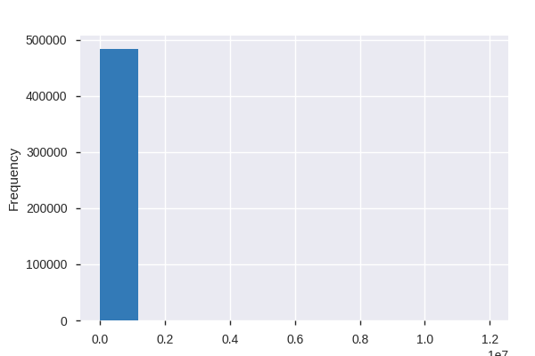

**Common Values**

| Value | Count | Frequency (%) |  |
| --- | --- | --- | --- |
| 60.0 | 4904 | 0.9% |  |
| 70.0 | 4497 | 0.8% |  |
| 80.0 | 4441 | 0.8% |  |
| 90.0 | 4387 | 0.8% |  |
| 100.0 | 4354 | 0.8% |  |
| 75.0 | 4306 | 0.8% |  |
| 85.0 | 4303 | 0.8% |  |
| 65.0 | 4164 | 0.8% |  |
| 0.0 | 4112 | 0.8% |  |
| 50.0 | 4084 | 0.8% |  |
| Other values (3003) | 440115 | 81.9% |  |
| (Missing) | 53414 | 9.9% |  |

**Extreme Values**

Minimum 5 values

| Value | Count | Frequency (%) |  |
| --- | --- | --- | --- |
| -17862.0 | 1 | 0.0% |  |
| -6876.0 | 1 | 0.0% |  |
| -3455.0 | 1 | 0.0% |  |
| -2527.0 | 1 | 0.0% |  |
| -2172.0 | 1 | 0.0% |  |

Maximum 5 values

| Value | Count | Frequency (%) |  |
| --- | --- | --- | --- |
| 120000.0 | 3 | 0.0% |  |
| 200512.0 | 1 | 0.0% |  |
| 230089.0 | 1 | 0.0% |  |
| 1461491.0 | 1 | 0.0% |  |
| 11970638.0 | 1 | 0.0% |  |

debt_to_income_ratio  
Categorical

| Distinct count | 21 |
| --- | --- |
| Unique (%) | 0.0% |
| Missing (%) | 27.4% |
| Missing (n) | 147171 |

| 20%-<30% | 57936 |
| --- | --- |
| 30%-<36% | 54662 |
| 50%-60% | 36290 |
| Other values (17) | 241022 |
| (Missing) | 147171 |

Toggle details

| Value | Count | Frequency (%) |  |
| --- | --- | --- | --- |
| 20%-<30% | 57936 | 10.8% |  |
| 30%-<36% | 54662 | 10.2% |  |
| 50%-60% | 36290 | 6.8% |  |
| >60% | 36172 | 6.7% |  |
| <20% | 23375 | 4.4% |  |
| Exempt | 15527 | 2.9% |  |
| 42 | 15049 | 2.8% |  |
| 49 | 14586 | 2.7% |  |
| 41 | 12558 | 2.3% |  |
| 40 | 12449 | 2.3% |  |
| Other values (10) | 111306 | 20.7% |  |
| (Missing) | 147171 | 27.4% |  |

applicant_credit_score_type  
Highly correlated

*This variable is highly correlated with `manufactured_home_land_property_interest` and should be ignored for analysis*

| Correlation | 0.99752 |
| --- | --- |

co-applicant_credit_score_type  
Highly correlated

*This variable is highly correlated with `applicant_credit_score_type` and should be ignored for analysis*

| Correlation | 0.99976 |
| --- | --- |

applicant_ethnicity-1  
Numeric

| Distinct count | 9 |
| --- | --- |
| Unique (%) | 0.0% |
| Missing (%) | 0.0% |
| Missing (n) | 208 |
| Infinite (%) | 0.0% |
| Infinite (n) | 0 |

| Mean | 2.3273 |
| --- | --- |
| Minimum | 1 |
| Maximum | 14 |
| Zeros (%) | 0.0% |

Toggle details

**Statistics**

Quantile statistics

| Minimum | 1 |
| --- | --- |
| 5-th percentile | 1 |
| Q1 | 2 |
| Median | 2 |
| Q3 | 2 |
| 95-th percentile | 4 |
| Maximum | 14 |
| Range | 13 |
| Interquartile range | 0 |

Descriptive statistics

| Standard deviation | 1.2592 |
| --- | --- |
| Coef of variation | 0.54107 |
| Kurtosis | 53.282 |
| Mean | 2.3273 |
| MAD | 0.6436 |
| Skewness | 6.3442 |
| Sum | 1249400 |
| Variance | 1.5856 |
| Memory size | 4.1 MiB |

**Histogram**

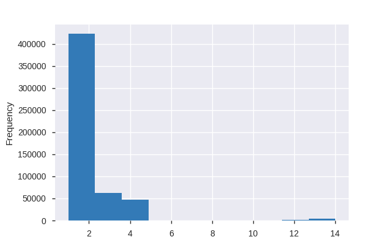

**Common Values**

| Value | Count | Frequency (%) |  |
| --- | --- | --- | --- |
| 2.0 | 388991 | 72.4% |  |
| 3.0 | 62026 | 11.5% |  |
| 4.0 | 46878 | 8.7% |  |
| 1.0 | 34252 | 6.4% |  |
| 14.0 | 3480 | 0.6% |  |
| 12.0 | 982 | 0.2% |  |
| 11.0 | 157 | 0.0% |  |
| 13.0 | 107 | 0.0% |  |
| (Missing) | 208 | 0.0% |  |

**Extreme Values**

Minimum 5 values

| Value | Count | Frequency (%) |  |
| --- | --- | --- | --- |
| 1.0 | 34252 | 6.4% |  |
| 2.0 | 388991 | 72.4% |  |
| 3.0 | 62026 | 11.5% |  |
| 4.0 | 46878 | 8.7% |  |
| 11.0 | 157 | 0.0% |  |

Maximum 5 values

| Value | Count | Frequency (%) |  |
| --- | --- | --- | --- |
| 4.0 | 46878 | 8.7% |  |
| 11.0 | 157 | 0.0% |  |
| 12.0 | 982 | 0.2% |  |
| 13.0 | 107 | 0.0% |  |
| 14.0 | 3480 | 0.6% |  |

applicant_ethnicity-2  
Numeric

| Distinct count | 7 |
| --- | --- |
| Unique (%) | 0.0% |
| Missing (%) | 97.8% |
| Missing (n) | 525024 |
| Infinite (%) | 0.0% |
| Infinite (n) | 0 |

| Mean | 12.645 |
| --- | --- |
| Minimum | 1 |
| Maximum | 14 |
| Zeros (%) | 0.0% |

Toggle details

**Statistics**

Quantile statistics

| Minimum | 1 |
| --- | --- |
| 5-th percentile | 11 |
| Q1 | 12 |
| Median | 14 |
| Q3 | 14 |
| 95-th percentile | 14 |
| Maximum | 14 |
| Range | 13 |
| Interquartile range | 2 |

Descriptive statistics

| Standard deviation | 2.3069 |
| --- | --- |
| Coef of variation | 0.18243 |
| Kurtosis | 13.56 |
| Mean | 12.645 |
| MAD | 1.439 |
| Skewness | -3.4459 |
| Sum | 152470 |
| Variance | 5.3216 |
| Memory size | 4.1 MiB |

**Histogram**

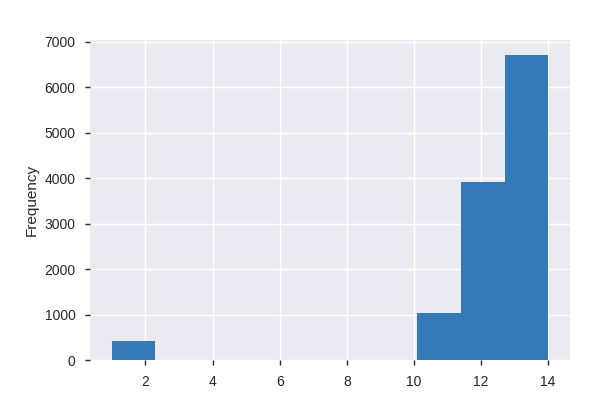

**Common Values**

| Value | Count | Frequency (%) |  |
| --- | --- | --- | --- |
| 14.0 | 6297 | 1.2% |  |
| 12.0 | 3909 | 0.7% |  |
| 11.0 | 1027 | 0.2% |  |
| 13.0 | 410 | 0.1% |  |
| 2.0 | 359 | 0.1% |  |
| 1.0 | 55 | 0.0% |  |
| (Missing) | 525024 | 97.8% |  |

**Extreme Values**

Minimum 5 values

| Value | Count | Frequency (%) |  |
| --- | --- | --- | --- |
| 1.0 | 55 | 0.0% |  |
| 2.0 | 359 | 0.1% |  |
| 11.0 | 1027 | 0.2% |  |
| 12.0 | 3909 | 0.7% |  |
| 13.0 | 410 | 0.1% |  |

Maximum 5 values

| Value | Count | Frequency (%) |  |
| --- | --- | --- | --- |
| 2.0 | 359 | 0.1% |  |
| 11.0 | 1027 | 0.2% |  |
| 12.0 | 3909 | 0.7% |  |
| 13.0 | 410 | 0.1% |  |
| 14.0 | 6297 | 1.2% |  |

applicant_ethnicity-3  
Numeric

| Distinct count | 7 |
| --- | --- |
| Unique (%) | 0.0% |
| Missing (%) | 100.0% |
| Missing (n) | 536813 |
| Infinite (%) | 0.0% |
| Infinite (n) | 0 |

| Mean | 12.94 |
| --- | --- |
| Minimum | 1 |
| Maximum | 14 |
| Zeros (%) | 0.0% |

Toggle details

**Statistics**

Quantile statistics

| Minimum | 1 |
| --- | --- |
| 5-th percentile | 11 |
| Q1 | 12 |
| Median | 13 |
| Q3 | 14 |
| 95-th percentile | 14 |
| Maximum | 14 |
| Range | 13 |
| Interquartile range | 2 |

Descriptive statistics

| Standard deviation | 1.8041 |
| --- | --- |
| Coef of variation | 0.13942 |
| Kurtosis | 25.177 |
| Mean | 12.94 |
| MAD | 1.039 |
| Skewness | -4.456 |
| Sum | 3468 |
| Variance | 3.2548 |
| Memory size | 4.1 MiB |

**Histogram**

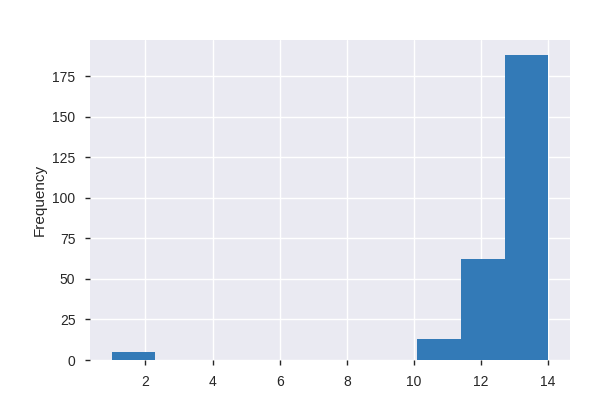

**Common Values**

| Value | Count | Frequency (%) |  |
| --- | --- | --- | --- |
| 14.0 | 128 | 0.0% |  |
| 12.0 | 62 | 0.0% |  |
| 13.0 | 60 | 0.0% |  |
| 11.0 | 13 | 0.0% |  |
| 2.0 | 4 | 0.0% |  |
| 1.0 | 1 | 0.0% |  |
| (Missing) | 536813 | 100.0% |  |

**Extreme Values**

Minimum 5 values

| Value | Count | Frequency (%) |  |
| --- | --- | --- | --- |
| 1.0 | 1 | 0.0% |  |
| 2.0 | 4 | 0.0% |  |
| 11.0 | 13 | 0.0% |  |
| 12.0 | 62 | 0.0% |  |
| 13.0 | 60 | 0.0% |  |

Maximum 5 values

| Value | Count | Frequency (%) |  |
| --- | --- | --- | --- |
| 2.0 | 4 | 0.0% |  |
| 11.0 | 13 | 0.0% |  |
| 12.0 | 62 | 0.0% |  |
| 13.0 | 60 | 0.0% |  |
| 14.0 | 128 | 0.0% |  |

applicant_ethnicity-4  
Highly correlated

*This variable is highly correlated with `applicant_ethnicity-3` and should be ignored for analysis*

| Correlation | 0.91826 |
| --- | --- |

applicant_ethnicity-5  
Highly correlated

*This variable is highly correlated with `applicant_ethnicity-4` and should be ignored for analysis*

| Correlation | 1 |
| --- | --- |

co-applicant_ethnicity-1  
Numeric

| Distinct count | 10 |
| --- | --- |
| Unique (%) | 0.0% |
| Missing (%) | 0.0% |
| Missing (n) | 69 |
| Infinite (%) | 0.0% |
| Infinite (n) | 0 |

| Mean | 3.8183 |
| --- | --- |
| Minimum | 1 |
| Maximum | 14 |
| Zeros (%) | 0.0% |

Toggle details

**Statistics**

Quantile statistics

| Minimum | 1 |
| --- | --- |
| 5-th percentile | 2 |
| Q1 | 2 |
| Median | 5 |
| Q3 | 5 |
| 95-th percentile | 5 |
| Maximum | 14 |
| Range | 13 |
| Interquartile range | 3 |

Descriptive statistics

| Standard deviation | 1.5275 |
| --- | --- |
| Coef of variation | 0.40005 |
| Kurtosis | 3.4853 |
| Mean | 3.8183 |
| MAD | 1.3653 |
| Skewness | 0.37813 |
| Sum | 2050500 |
| Variance | 2.3333 |
| Memory size | 4.1 MiB |

**Histogram**

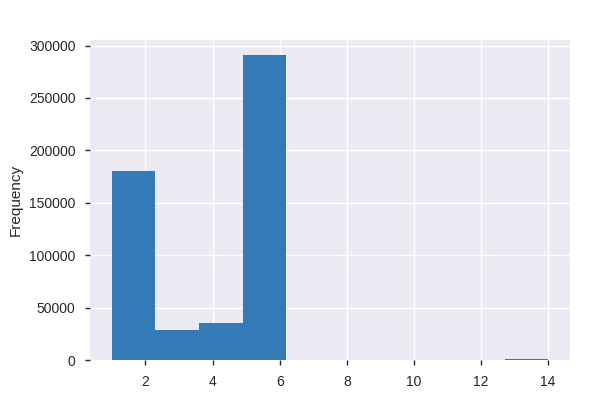

**Common Values**

| Value | Count | Frequency (%) |  |
| --- | --- | --- | --- |
| 5.0 | 290782 | 54.1% |  |
| 2.0 | 165885 | 30.9% |  |
| 4.0 | 35023 | 6.5% |  |
| 3.0 | 28950 | 5.4% |  |
| 1.0 | 14648 | 2.7% |  |
| 14.0 | 1261 | 0.2% |  |
| 12.0 | 345 | 0.1% |  |
| 11.0 | 66 | 0.0% |  |
| 13.0 | 52 | 0.0% |  |
| (Missing) | 69 | 0.0% |  |

**Extreme Values**

Minimum 5 values

| Value | Count | Frequency (%) |  |
| --- | --- | --- | --- |
| 1.0 | 14648 | 2.7% |  |
| 2.0 | 165885 | 30.9% |  |
| 3.0 | 28950 | 5.4% |  |
| 4.0 | 35023 | 6.5% |  |
| 5.0 | 290782 | 54.1% |  |

Maximum 5 values

| Value | Count | Frequency (%) |  |
| --- | --- | --- | --- |
| 5.0 | 290782 | 54.1% |  |
| 11.0 | 66 | 0.0% |  |
| 12.0 | 345 | 0.1% |  |
| 13.0 | 52 | 0.0% |  |
| 14.0 | 1261 | 0.2% |  |

co-applicant_ethnicity-2  
Numeric

| Distinct count | 7 |
| --- | --- |
| Unique (%) | 0.0% |
| Missing (%) | 99.2% |
| Missing (n) | 532543 |
| Infinite (%) | 0.0% |
| Infinite (n) | 0 |

| Mean | 12.534 |
| --- | --- |
| Minimum | 1 |
| Maximum | 14 |
| Zeros (%) | 0.0% |

Toggle details

**Statistics**

Quantile statistics

| Minimum | 1 |
| --- | --- |
| 5-th percentile | 11 |
| Q1 | 12 |
| Median | 14 |
| Q3 | 14 |
| 95-th percentile | 14 |
| Maximum | 14 |
| Range | 13 |
| Interquartile range | 2 |

Descriptive statistics

| Standard deviation | 2.5517 |
| --- | --- |
| Coef of variation | 0.20358 |
| Kurtosis | 10.803 |
| Mean | 12.534 |
| MAD | 1.5619 |
| Skewness | -3.1934 |
| Sum | 56881 |
| Variance | 6.5112 |
| Memory size | 4.1 MiB |

**Histogram**

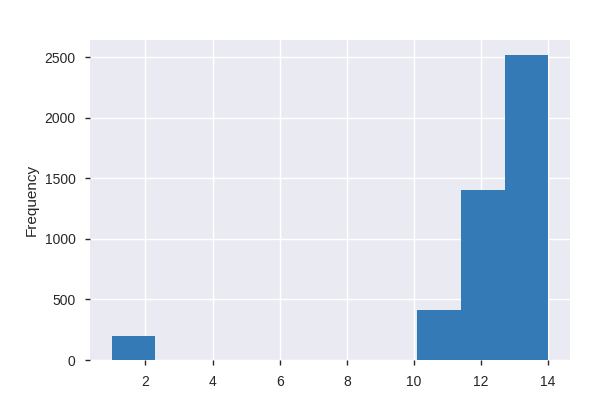

**Common Values**

| Value | Count | Frequency (%) |  |
| --- | --- | --- | --- |
| 14.0 | 2372 | 0.4% |  |
| 12.0 | 1403 | 0.3% |  |
| 11.0 | 416 | 0.1% |  |
| 2.0 | 174 | 0.0% |  |
| 13.0 | 145 | 0.0% |  |
| 1.0 | 28 | 0.0% |  |
| (Missing) | 532543 | 99.2% |  |

**Extreme Values**

Minimum 5 values

| Value | Count | Frequency (%) |  |
| --- | --- | --- | --- |
| 1.0 | 28 | 0.0% |  |
| 2.0 | 174 | 0.0% |  |
| 11.0 | 416 | 0.1% |  |
| 12.0 | 1403 | 0.3% |  |
| 13.0 | 145 | 0.0% |  |

Maximum 5 values

| Value | Count | Frequency (%) |  |
| --- | --- | --- | --- |
| 2.0 | 174 | 0.0% |  |
| 11.0 | 416 | 0.1% |  |
| 12.0 | 1403 | 0.3% |  |
| 13.0 | 145 | 0.0% |  |
| 14.0 | 2372 | 0.4% |  |

co-applicant_ethnicity-3  
Numeric

| Distinct count | 7 |
| --- | --- |
| Unique (%) | 0.0% |
| Missing (%) | 100.0% |
| Missing (n) | 536991 |
| Infinite (%) | 0.0% |
| Infinite (n) | 0 |

| Mean | 12.711 |
| --- | --- |
| Minimum | 1 |
| Maximum | 14 |
| Zeros (%) | 0.0% |

Toggle details

**Statistics**

Quantile statistics

| Minimum | 1 |
| --- | --- |
| 5-th percentile | 11.45 |
| Q1 | 12 |
| Median | 13 |
| Q3 | 14 |
| 95-th percentile | 14 |
| Maximum | 14 |
| Range | 13 |
| Interquartile range | 2 |

Descriptive statistics

| Standard deviation | 2.2498 |
| --- | --- |
| Coef of variation | 0.177 |
| Kurtosis | 18.131 |
| Mean | 12.711 |
| MAD | 1.2232 |
| Skewness | -4.0378 |
| Sum | 1144 |
| Variance | 5.0617 |
| Memory size | 4.1 MiB |

**Histogram**

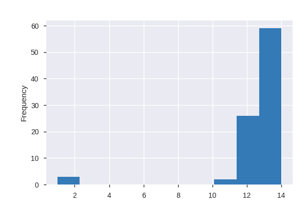

**Common Values**

| Value | Count | Frequency (%) |  |
| --- | --- | --- | --- |
| 14.0 | 38 | 0.0% |  |
| 12.0 | 26 | 0.0% |  |
| 13.0 | 21 | 0.0% |  |
| 11.0 | 2 | 0.0% |  |
| 2.0 | 2 | 0.0% |  |
| 1.0 | 1 | 0.0% |  |
| (Missing) | 536991 | 100.0% |  |

**Extreme Values**

Minimum 5 values

| Value | Count | Frequency (%) |  |
| --- | --- | --- | --- |
| 1.0 | 1 | 0.0% |  |
| 2.0 | 2 | 0.0% |  |
| 11.0 | 2 | 0.0% |  |
| 12.0 | 26 | 0.0% |  |
| 13.0 | 21 | 0.0% |  |

Maximum 5 values

| Value | Count | Frequency (%) |  |
| --- | --- | --- | --- |
| 2.0 | 2 | 0.0% |  |
| 11.0 | 2 | 0.0% |  |
| 12.0 | 26 | 0.0% |  |
| 13.0 | 21 | 0.0% |  |
| 14.0 | 38 | 0.0% |  |

co-applicant_ethnicity-4  
Highly correlated

*This variable is highly correlated with `co-applicant_ethnicity-3` and should be ignored for analysis*

| Correlation | 1 |
| --- | --- |

co-applicant_ethnicity-5  
Boolean

| Distinct count | 2 |
| --- | --- |
| Unique (%) | 0.0% |
| Missing (%) | 100.0% |
| Missing (n) | 537080 |

| Mean | 14 |
| --- | --- |

| 14.0 | 1 |
| --- | --- |
| (Missing) | 537080 |

Toggle details

| Value | Count | Frequency (%) |  |
| --- | --- | --- | --- |
| 14.0 | 1 | 0.0% |  |
| (Missing) | 537080 | 100.0% |  |

applicant_ethnicity_observed  
Numeric

| Distinct count | 3 |
| --- | --- |
| Unique (%) | 0.0% |
| Missing (%) | 0.0% |
| Missing (n) | 0 |
| Infinite (%) | 0.0% |
| Infinite (n) | 0 |

| Mean | 2.0737 |
| --- | --- |
| Minimum | 1 |
| Maximum | 3 |
| Zeros (%) | 0.0% |

Toggle details

**Statistics**

Quantile statistics

| Minimum | 1 |
| --- | --- |
| 5-th percentile | 1 |
| Q1 | 2 |
| Median | 2 |
| Q3 | 2 |
| 95-th percentile | 3 |
| Maximum | 3 |
| Range | 2 |
| Interquartile range | 0 |

Descriptive statistics

| Standard deviation | 0.47005 |
| --- | --- |
| Coef of variation | 0.22667 |
| Kurtosis | 1.3413 |
| Mean | 2.0737 |
| MAD | 0.27799 |
| Skewness | 0.23549 |
| Sum | 1113761 |
| Variance | 0.22095 |
| Memory size | 4.1 MiB |

**Histogram**

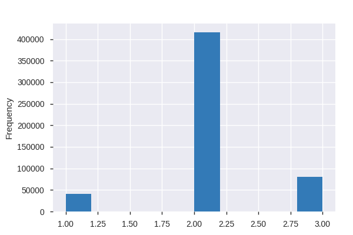

**Common Values**

| Value | Count | Frequency (%) |  |
| --- | --- | --- | --- |
| 2 | 415494 | 77.4% |  |
| 3 | 80593 | 15.0% |  |
| 1 | 40994 | 7.6% |  |

**Extreme Values**

Minimum 5 values

| Value | Count | Frequency (%) |  |
| --- | --- | --- | --- |
| 1 | 40994 | 7.6% |  |
| 2 | 415494 | 77.4% |  |
| 3 | 80593 | 15.0% |  |

Maximum 5 values

| Value | Count | Frequency (%) |  |
| --- | --- | --- | --- |
| 1 | 40994 | 7.6% |  |
| 2 | 415494 | 77.4% |  |
| 3 | 80593 | 15.0% |  |

co-applicant_ethnicity_observed  
Numeric

| Distinct count | 4 |
| --- | --- |
| Unique (%) | 0.0% |
| Missing (%) | 0.0% |
| Missing (n) | 0 |
| Infinite (%) | 0.0% |
| Infinite (n) | 0 |

| Mean | 3.1427 |
| --- | --- |
| Minimum | 1 |
| Maximum | 4 |
| Zeros (%) | 0.0% |

Toggle details

**Statistics**

Quantile statistics

| Minimum | 1 |
| --- | --- |
| 5-th percentile | 2 |
| Q1 | 2 |
| Median | 4 |
| Q3 | 4 |
| 95-th percentile | 4 |
| Maximum | 4 |
| Range | 3 |
| Interquartile range | 2 |

Descriptive statistics

| Standard deviation | 0.9919 |
| --- | --- |
| Coef of variation | 0.31562 |
| Kurtosis | -1.4108 |
| Mean | 3.1427 |
| MAD | 0.92833 |
| Skewness | -0.48527 |
| Sum | 1687873 |
| Variance | 0.98386 |
| Memory size | 4.1 MiB |

**Histogram**

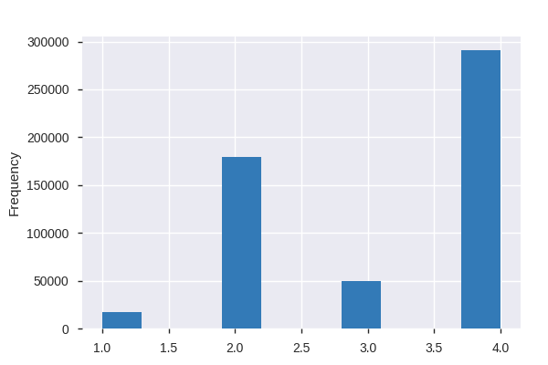

**Common Values**

| Value | Count | Frequency (%) |  |
| --- | --- | --- | --- |
| 4 | 290782 | 54.1% |  |
| 2 | 179740 | 33.5% |  |
| 3 | 49353 | 9.2% |  |
| 1 | 17206 | 3.2% |  |

**Extreme Values**

Minimum 5 values

| Value | Count | Frequency (%) |  |
| --- | --- | --- | --- |
| 1 | 17206 | 3.2% |  |
| 2 | 179740 | 33.5% |  |
| 3 | 49353 | 9.2% |  |
| 4 | 290782 | 54.1% |  |

Maximum 5 values

| Value | Count | Frequency (%) |  |
| --- | --- | --- | --- |
| 1 | 17206 | 3.2% |  |
| 2 | 179740 | 33.5% |  |
| 3 | 49353 | 9.2% |  |
| 4 | 290782 | 54.1% |  |

applicant_race-1  
Numeric

| Distinct count | 19 |
| --- | --- |
| Unique (%) | 0.0% |
| Missing (%) | 0.0% |
| Missing (n) | 107 |
| Infinite (%) | 0.0% |
| Infinite (n) | 0 |

| Mean | 5.2061 |
| --- | --- |
| Minimum | 1 |
| Maximum | 44 |
| Zeros (%) | 0.0% |

Toggle details

**Statistics**

Quantile statistics

| Minimum | 1 |
| --- | --- |
| 5-th percentile | 2 |
| Q1 | 5 |
| Median | 5 |
| Q3 | 5 |
| 95-th percentile | 7 |
| Maximum | 44 |
| Range | 43 |
| Interquartile range | 0 |

Descriptive statistics

| Standard deviation | 2.8326 |
| --- | --- |
| Coef of variation | 0.54408 |
| Kurtosis | 86.522 |
| Mean | 5.2061 |
| MAD | 1.0462 |
| Skewness | 7.8605 |
| Sum | 2795500 |
| Variance | 8.0234 |
| Memory size | 4.1 MiB |

**Histogram**

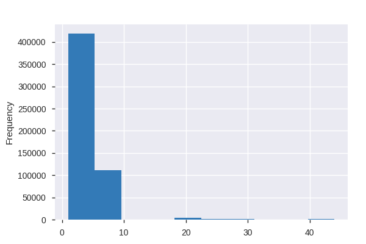

**Common Values**

| Value | Count | Frequency (%) |  |
| --- | --- | --- | --- |
| 5.0 | 342320 | 63.7% |  |
| 6.0 | 64340 | 12.0% |  |
| 7.0 | 46846 | 8.7% |  |
| 2.0 | 37681 | 7.0% |  |
| 3.0 | 35238 | 6.6% |  |
| 1.0 | 2483 | 0.5% |  |
| 21.0 | 2373 | 0.4% |  |
| 22.0 | 1508 | 0.3% |  |
| 27.0 | 1193 | 0.2% |  |
| 4.0 | 1121 | 0.2% |  |
| Other values (8) | 1871 | 0.3% |  |

**Extreme Values**

Minimum 5 values

| Value | Count | Frequency (%) |  |
| --- | --- | --- | --- |
| 1.0 | 2483 | 0.5% |  |
| 2.0 | 37681 | 7.0% |  |
| 3.0 | 35238 | 6.6% |  |
| 4.0 | 1121 | 0.2% |  |
| 5.0 | 342320 | 63.7% |  |

Maximum 5 values

| Value | Count | Frequency (%) |  |
| --- | --- | --- | --- |
| 27.0 | 1193 | 0.2% |  |
| 41.0 | 5 | 0.0% |  |
| 42.0 | 18 | 0.0% |  |
| 43.0 | 6 | 0.0% |  |
| 44.0 | 1057 | 0.2% |  |

applicant_race-2  
Highly correlated

*This variable is highly correlated with `applicant_ethnicity-5` and should be ignored for analysis*

| Correlation | 0.99028 |
| --- | --- |

applicant_race-3  
Numeric

| Distinct count | 16 |
| --- | --- |
| Unique (%) | 0.0% |
| Missing (%) | 99.8% |
| Missing (n) | 535974 |
| Infinite (%) | 0.0% |
| Infinite (n) | 0 |

| Mean | 21.963 |
| --- | --- |
| Minimum | 1 |
| Maximum | 44 |
| Zeros (%) | 0.0% |

Toggle details

**Statistics**

Quantile statistics

| Minimum | 1 |
| --- | --- |
| 5-th percentile | 5 |
| Q1 | 21 |
| Median | 23 |
| Q3 | 27 |
| 95-th percentile | 44 |
| Maximum | 44 |
| Range | 43 |
| Interquartile range | 6 |

Descriptive statistics

| Standard deviation | 11.022 |
| --- | --- |
| Coef of variation | 0.50183 |
| Kurtosis | -0.0092185 |
| Mean | 21.963 |
| MAD | 7.5521 |
| Skewness | 0.034915 |
| Sum | 24313 |
| Variance | 121.48 |
| Memory size | 4.1 MiB |

**Histogram**

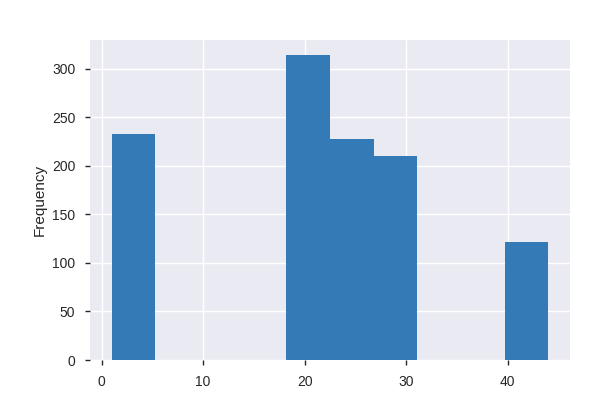

**Common Values**

| Value | Count | Frequency (%) |  |
| --- | --- | --- | --- |
| 27.0 | 210 | 0.0% |  |
| 5.0 | 179 | 0.0% |  |
| 22.0 | 172 | 0.0% |  |
| 21.0 | 142 | 0.0% |  |
| 44.0 | 103 | 0.0% |  |
| 23.0 | 100 | 0.0% |  |
| 25.0 | 59 | 0.0% |  |
| 24.0 | 44 | 0.0% |  |
| 3.0 | 31 | 0.0% |  |
| 26.0 | 25 | 0.0% |  |
| Other values (5) | 42 | 0.0% |  |
| (Missing) | 535974 | 99.8% |  |

**Extreme Values**

Minimum 5 values

| Value | Count | Frequency (%) |  |
| --- | --- | --- | --- |
| 1.0 | 2 | 0.0% |  |
| 3.0 | 31 | 0.0% |  |
| 4.0 | 21 | 0.0% |  |
| 5.0 | 179 | 0.0% |  |
| 21.0 | 142 | 0.0% |  |

Maximum 5 values

| Value | Count | Frequency (%) |  |
| --- | --- | --- | --- |
| 27.0 | 210 | 0.0% |  |
| 41.0 | 11 | 0.0% |  |
| 42.0 | 5 | 0.0% |  |
| 43.0 | 3 | 0.0% |  |
| 44.0 | 103 | 0.0% |  |

applicant_race-4  
Numeric

| Distinct count | 13 |
| --- | --- |
| Unique (%) | 0.0% |
| Missing (%) | 100.0% |
| Missing (n) | 536965 |
| Infinite (%) | 0.0% |
| Infinite (n) | 0 |

| Mean | 21.345 |
| --- | --- |
| Minimum | 4 |
| Maximum | 44 |
| Zeros (%) | 0.0% |

Toggle details

**Statistics**

Quantile statistics

| Minimum | 4 |
| --- | --- |
| 5-th percentile | 4 |
| Q1 | 5 |
| Median | 22 |
| Q3 | 27 |
| 95-th percentile | 44 |
| Maximum | 44 |
| Range | 40 |
| Interquartile range | 22 |

Descriptive statistics

| Standard deviation | 14.599 |
| --- | --- |
| Coef of variation | 0.68396 |
| Kurtosis | -1.1393 |
| Mean | 21.345 |
| MAD | 11.734 |
| Skewness | 0.25429 |
| Sum | 2476 |
| Variance | 213.13 |
| Memory size | 4.1 MiB |

**Histogram**

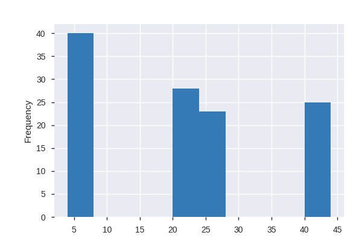

**Common Values**

| Value | Count | Frequency (%) |  |
| --- | --- | --- | --- |
| 4.0 | 23 | 0.0% |  |
| 44.0 | 22 | 0.0% |  |
| 5.0 | 17 | 0.0% |  |
| 27.0 | 11 | 0.0% |  |
| 21.0 | 11 | 0.0% |  |
| 22.0 | 9 | 0.0% |  |
| 23.0 | 8 | 0.0% |  |
| 25.0 | 6 | 0.0% |  |
| 24.0 | 5 | 0.0% |  |
| 41.0 | 2 | 0.0% |  |
| Other values (2) | 2 | 0.0% |  |
| (Missing) | 536965 | 100.0% |  |

**Extreme Values**

Minimum 5 values

| Value | Count | Frequency (%) |  |
| --- | --- | --- | --- |
| 4.0 | 23 | 0.0% |  |
| 5.0 | 17 | 0.0% |  |
| 21.0 | 11 | 0.0% |  |
| 22.0 | 9 | 0.0% |  |
| 23.0 | 8 | 0.0% |  |

Maximum 5 values

| Value | Count | Frequency (%) |  |
| --- | --- | --- | --- |
| 26.0 | 1 | 0.0% |  |
| 27.0 | 11 | 0.0% |  |
| 41.0 | 2 | 0.0% |  |
| 43.0 | 1 | 0.0% |  |
| 44.0 | 22 | 0.0% |  |

applicant_race-5  
Numeric

| Distinct count | 9 |
| --- | --- |
| Unique (%) | 0.0% |
| Missing (%) | 100.0% |
| Missing (n) | 537042 |
| Infinite (%) | 0.0% |
| Infinite (n) | 0 |

| Mean | 16.897 |
| --- | --- |
| Minimum | 5 |
| Maximum | 44 |
| Zeros (%) | 0.0% |

Toggle details

**Statistics**

Quantile statistics

| Minimum | 5 |
| --- | --- |
| 5-th percentile | 5 |
| Q1 | 5 |
| Median | 5 |
| Q3 | 24 |
| 95-th percentile | 44 |
| Maximum | 44 |
| Range | 39 |
| Interquartile range | 19 |

Descriptive statistics

| Standard deviation | 14.634 |
| --- | --- |
| Coef of variation | 0.86603 |
| Kurtosis | -0.81738 |
| Mean | 16.897 |
| MAD | 12.813 |
| Skewness | 0.79682 |
| Sum | 659 |
| Variance | 214.15 |
| Memory size | 4.1 MiB |

**Histogram**

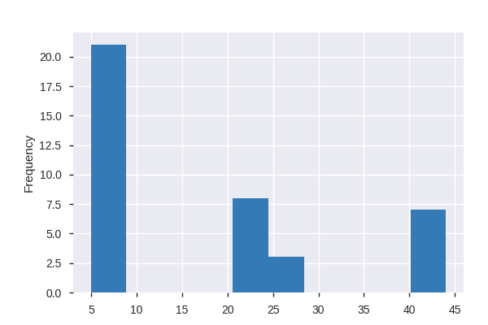

**Common Values**

| Value | Count | Frequency (%) |  |
| --- | --- | --- | --- |
| 5.0 | 21 | 0.0% |  |
| 44.0 | 4 | 0.0% |  |
| 23.0 | 3 | 0.0% |  |
| 21.0 | 3 | 0.0% |  |
| 41.0 | 3 | 0.0% |  |
| 27.0 | 2 | 0.0% |  |
| 22.0 | 2 | 0.0% |  |
| 25.0 | 1 | 0.0% |  |
| (Missing) | 537042 | 100.0% |  |

**Extreme Values**

Minimum 5 values

| Value | Count | Frequency (%) |  |
| --- | --- | --- | --- |
| 5.0 | 21 | 0.0% |  |
| 21.0 | 3 | 0.0% |  |
| 22.0 | 2 | 0.0% |  |
| 23.0 | 3 | 0.0% |  |
| 25.0 | 1 | 0.0% |  |

Maximum 5 values

| Value | Count | Frequency (%) |  |
| --- | --- | --- | --- |
| 23.0 | 3 | 0.0% |  |
| 25.0 | 1 | 0.0% |  |
| 27.0 | 2 | 0.0% |  |
| 41.0 | 3 | 0.0% |  |
| 44.0 | 4 | 0.0% |  |

co-applicant_race-1  
Highly correlated

*This variable is highly correlated with `co-applicant_ethnicity-4` and should be ignored for analysis*

| Correlation | 1 |
| --- | --- |

co-applicant_race-2  
Numeric

| Distinct count | 17 |
| --- | --- |
| Unique (%) | 0.0% |
| Missing (%) | 98.4% |
| Missing (n) | 528406 |
| Infinite (%) | 0.0% |
| Infinite (n) | 0 |

| Mean | 20.761 |
| --- | --- |
| Minimum | 1 |
| Maximum | 44 |
| Zeros (%) | 0.0% |

Toggle details

**Statistics**

Quantile statistics

| Minimum | 1 |
| --- | --- |
| 5-th percentile | 5 |
| Q1 | 21 |
| Median | 22 |
| Q3 | 23 |
| 95-th percentile | 27 |
| Maximum | 44 |
| Range | 43 |
| Interquartile range | 2 |

Descriptive statistics

| Standard deviation | 7.3852 |
| --- | --- |
| Coef of variation | 0.35572 |
| Kurtosis | 2.4493 |
| Mean | 20.761 |
| MAD | 4.378 |
| Skewness | -0.64463 |
| Sum | 180110 |
| Variance | 54.541 |
| Memory size | 4.1 MiB |

**Histogram**

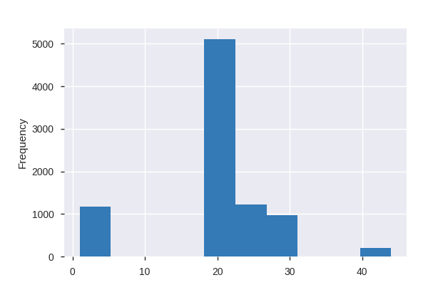

**Common Values**

| Value | Count | Frequency (%) |  |
| --- | --- | --- | --- |
| 22.0 | 2803 | 0.5% |  |
| 21.0 | 2300 | 0.4% |  |
| 5.0 | 975 | 0.2% |  |
| 27.0 | 968 | 0.2% |  |
| 25.0 | 540 | 0.1% |  |
| 23.0 | 462 | 0.1% |  |
| 44.0 | 180 | 0.0% |  |
| 26.0 | 131 | 0.0% |  |
| 24.0 | 96 | 0.0% |  |
| 3.0 | 88 | 0.0% |  |
| Other values (6) | 132 | 0.0% |  |
| (Missing) | 528406 | 98.4% |  |

**Extreme Values**

Minimum 5 values

| Value | Count | Frequency (%) |  |
| --- | --- | --- | --- |
| 1.0 | 32 | 0.0% |  |
| 2.0 | 43 | 0.0% |  |
| 3.0 | 88 | 0.0% |  |
| 4.0 | 37 | 0.0% |  |
| 5.0 | 975 | 0.2% |  |

Maximum 5 values

| Value | Count | Frequency (%) |  |
| --- | --- | --- | --- |
| 27.0 | 968 | 0.2% |  |
| 41.0 | 5 | 0.0% |  |
| 42.0 | 7 | 0.0% |  |
| 43.0 | 8 | 0.0% |  |
| 44.0 | 180 | 0.0% |  |

co-applicant_race-3  
Highly correlated

*This variable is highly correlated with `applicant_race-5` and should be ignored for analysis*

| Correlation | 1 |
| --- | --- |

co-applicant_race-4  
Highly correlated

*This variable is highly correlated with `applicant_race-5` and should be ignored for analysis*

| Correlation | 1 |
| --- | --- |

co-applicant_race-5  
Highly correlated

*This variable is highly correlated with `co-applicant_race-4` and should be ignored for analysis*

| Correlation | 0.9538 |
| --- | --- |

applicant_race_observed  
Highly correlated

*This variable is highly correlated with `co-applicant_race-5` and should be ignored for analysis*

| Correlation | 0.94141 |
| --- | --- |

co-applicant_race_observed  
Highly correlated

*This variable is highly correlated with `co-applicant_race-5` and should be ignored for analysis*

| Correlation | 0.94141 |
| --- | --- |

applicant_sex  
Highly correlated

*This variable is highly correlated with `co-applicant_ethnicity-4` and should be ignored for analysis*

| Correlation | 1 |
| --- | --- |

co-applicant_sex  
Highly correlated

*This variable is highly correlated with `co-applicant_race_observed` and should be ignored for analysis*

| Correlation | 0.93907 |
| --- | --- |

applicant_sex_observed  
Highly correlated

*This variable is highly correlated with `applicant_race_observed` and should be ignored for analysis*

| Correlation | 0.97696 |
| --- | --- |

co-applicant_sex_observed  
Highly correlated

*This variable is highly correlated with `co-applicant_sex` and should be ignored for analysis*

| Correlation | 0.9419 |
| --- | --- |

applicant_age  
Categorical

| Distinct count | 8 |
| --- | --- |
| Unique (%) | 0.0% |
| Missing (%) | 0.0% |
| Missing (n) | 0 |

| 45-54 | 115764 |
| --- | --- |
| 35-44 | 114737 |
| 55-64 | 92696 |
| Other values (5) | 213884 |

Toggle details

| Value | Count | Frequency (%) |  |
| --- | --- | --- | --- |
| 45-54 | 115764 | 21.6% |  |
| 35-44 | 114737 | 21.4% |  |
| 55-64 | 92696 | 17.3% |  |
| 25-34 | 90810 | 16.9% |  |
| 8888 | 49419 | 9.2% |  |
| 65-74 | 47859 | 8.9% |  |
| >74 | 16806 | 3.1% |  |
| <25 | 8990 | 1.7% |  |

co-applicant_age  
Categorical

| Distinct count | 9 |
| --- | --- |
| Unique (%) | 0.0% |
| Missing (%) | 0.0% |
| Missing (n) | 0 |

| 9999 | 288493 |
| --- | --- |
| 35-44 | 47945 |
| 45-54 | 47067 |
| Other values (6) | 153576 |

Toggle details

| Value | Count | Frequency (%) |  |
| --- | --- | --- | --- |
| 9999 | 288493 | 53.7% |  |
| 35-44 | 47945 | 8.9% |  |
| 45-54 | 47067 | 8.8% |  |
| 25-34 | 41702 | 7.8% |  |
| 55-64 | 40681 | 7.6% |  |
| 8888 | 38031 | 7.1% |  |
| 65-74 | 21903 | 4.1% |  |
| >74 | 6897 | 1.3% |  |
| <25 | 4362 | 0.8% |  |

applicant_age_above_62  
Categorical

| Distinct count | 3 |
| --- | --- |
| Unique (%) | 0.0% |
| Missing (%) | 9.2% |
| Missing (n) | 49419 |

| No | 400671 |
| --- | --- |
| Yes | 86991 |
| (Missing) | 49419 |

Toggle details

| Value | Count | Frequency (%) |  |
| --- | --- | --- | --- |
| No | 400671 | 74.6% |  |
| Yes | 86991 | 16.2% |  |
| (Missing) | 49419 | 9.2% |  |

co-applicant_age_above_62  
Categorical

| Distinct count | 3 |
| --- | --- |
| Unique (%) | 0.0% |
| Missing (%) | 60.8% |
| Missing (n) | 326524 |

| No | 171424 |
| --- | --- |
| Yes | 39133 |
| (Missing) | 326524 |

Toggle details

| Value | Count | Frequency (%) |  |
| --- | --- | --- | --- |
| No | 171424 | 31.9% |  |
| Yes | 39133 | 7.3% |  |
| (Missing) | 326524 | 60.8% |  |

submission_of_application  
Highly correlated

*This variable is highly correlated with `co-applicant_credit_score_type` and should be ignored for analysis*

| Correlation | 0.99872 |
| --- | --- |

initially_payable_to_institution  
Highly correlated

*This variable is highly correlated with `submission_of_application` and should be ignored for analysis*

| Correlation | 1 |
| --- | --- |

aus-1  
Highly correlated

*This variable is highly correlated with `initially_payable_to_institution` and should be ignored for analysis*

| Correlation | 0.99775 |
| --- | --- |

aus-2  
Numeric

| Distinct count | 6 |
| --- | --- |
| Unique (%) | 0.0% |
| Missing (%) | 95.3% |
| Missing (n) | 511796 |
| Infinite (%) | 0.0% |
| Infinite (n) | 0 |

| Mean | 3.2647 |
| --- | --- |
| Minimum | 1 |
| Maximum | 5 |
| Zeros (%) | 0.0% |

Toggle details

**Statistics**

Quantile statistics

| Minimum | 1 |
| --- | --- |
| 5-th percentile | 1 |
| Q1 | 1 |
| Median | 3 |
| Q3 | 5 |
| 95-th percentile | 5 |
| Maximum | 5 |
| Range | 4 |
| Interquartile range | 4 |

Descriptive statistics

| Standard deviation | 1.7784 |
| --- | --- |
| Coef of variation | 0.54472 |
| Kurtosis | -1.8227 |
| Mean | 3.2647 |
| MAD | 1.729 |
| Skewness | -0.14319 |
| Sum | 82549 |
| Variance | 3.1626 |
| Memory size | 4.1 MiB |

**Histogram**

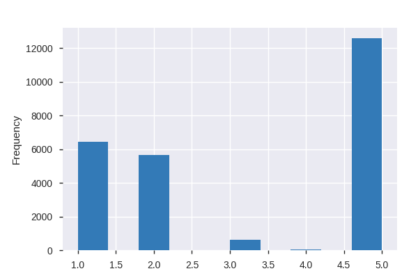

**Common Values**

| Value | Count | Frequency (%) |  |
| --- | --- | --- | --- |
| 5.0 | 12586 | 2.3% |  |
| 1.0 | 6432 | 1.2% |  |
| 2.0 | 5639 | 1.0% |  |
| 3.0 | 603 | 0.1% |  |
| 4.0 | 25 | 0.0% |  |
| (Missing) | 511796 | 95.3% |  |

**Extreme Values**

Minimum 5 values

| Value | Count | Frequency (%) |  |
| --- | --- | --- | --- |
| 1.0 | 6432 | 1.2% |  |
| 2.0 | 5639 | 1.0% |  |
| 3.0 | 603 | 0.1% |  |
| 4.0 | 25 | 0.0% |  |
| 5.0 | 12586 | 2.3% |  |

Maximum 5 values

| Value | Count | Frequency (%) |  |
| --- | --- | --- | --- |
| 1.0 | 6432 | 1.2% |  |
| 2.0 | 5639 | 1.0% |  |
| 3.0 | 603 | 0.1% |  |
| 4.0 | 25 | 0.0% |  |
| 5.0 | 12586 | 2.3% |  |

aus-3  
Numeric

| Distinct count | 6 |
| --- | --- |
| Unique (%) | 0.0% |
| Missing (%) | 98.3% |
| Missing (n) | 528144 |
| Infinite (%) | 0.0% |
| Infinite (n) | 0 |

| Mean | 3.1947 |
| --- | --- |
| Minimum | 1 |
| Maximum | 5 |
| Zeros (%) | 0.0% |

Toggle details

**Statistics**

Quantile statistics

| Minimum | 1 |
| --- | --- |
| 5-th percentile | 1 |
| Q1 | 2 |
| Median | 2 |
| Q3 | 5 |
| 95-th percentile | 5 |
| Maximum | 5 |
| Range | 4 |
| Interquartile range | 3 |

Descriptive statistics

| Standard deviation | 1.6117 |
| --- | --- |
| Coef of variation | 0.50451 |
| Kurtosis | -1.7773 |
| Mean | 3.1947 |
| MAD | 1.5579 |
| Skewness | 0.1274 |
| Sum | 28551 |
| Variance | 2.5977 |
| Memory size | 4.1 MiB |

**Histogram**

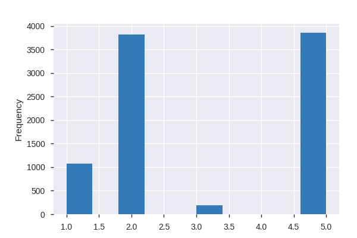

**Common Values**

| Value | Count | Frequency (%) |  |
| --- | --- | --- | --- |
| 5.0 | 3854 | 0.7% |  |
| 2.0 | 3815 | 0.7% |  |
| 1.0 | 1079 | 0.2% |  |
| 3.0 | 184 | 0.0% |  |
| 4.0 | 5 | 0.0% |  |
| (Missing) | 528144 | 98.3% |  |

**Extreme Values**

Minimum 5 values

| Value | Count | Frequency (%) |  |
| --- | --- | --- | --- |
| 1.0 | 1079 | 0.2% |  |
| 2.0 | 3815 | 0.7% |  |
| 3.0 | 184 | 0.0% |  |
| 4.0 | 5 | 0.0% |  |
| 5.0 | 3854 | 0.7% |  |

Maximum 5 values

| Value | Count | Frequency (%) |  |
| --- | --- | --- | --- |
| 1.0 | 1079 | 0.2% |  |
| 2.0 | 3815 | 0.7% |  |
| 3.0 | 184 | 0.0% |  |
| 4.0 | 5 | 0.0% |  |
| 5.0 | 3854 | 0.7% |  |

aus-4  
Highly correlated

*This variable is highly correlated with `aus-3` and should be ignored for analysis*

| Correlation | 0.95423 |
| --- | --- |

aus-5  
Highly correlated

*This variable is highly correlated with `aus-4` and should be ignored for analysis*

| Correlation | 0.96911 |
| --- | --- |

denial_reason-1  
Numeric

| Distinct count | 11 |
| --- | --- |
| Unique (%) | 0.0% |
| Missing (%) | 0.0% |
| Missing (n) | 0 |
| Infinite (%) | 0.0% |
| Infinite (n) | 0 |

| Mean | 25.996 |
| --- | --- |
| Minimum | 1 |
| Maximum | 1111 |
| Zeros (%) | 0.0% |

Toggle details

**Statistics**

Quantile statistics

| Minimum | 1 |
| --- | --- |
| 5-th percentile | 1 |
| Q1 | 10 |
| Median | 10 |
| Q3 | 10 |
| 95-th percentile | 10 |
| Maximum | 1111 |
| Range | 1110 |
| Interquartile range | 0 |

Descriptive statistics

| Standard deviation | 137.32 |
| --- | --- |
| Coef of variation | 5.2822 |
| Kurtosis | 58.425 |
| Mean | 25.996 |
| MAD | 34.194 |
| Skewness | 7.7715 |
| Sum | 13961852 |
| Variance | 18855 |
| Memory size | 4.1 MiB |

**Histogram**

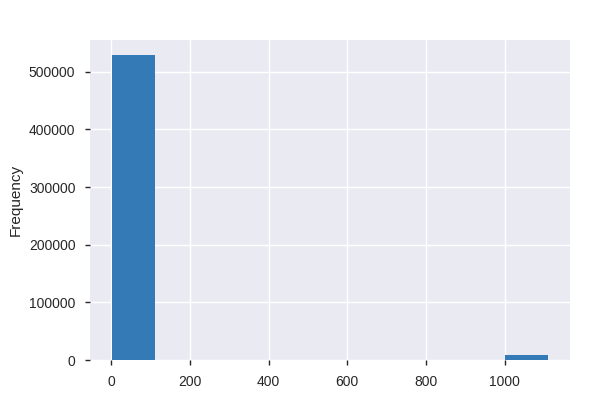

**Common Values**

| Value | Count | Frequency (%) |  |
| --- | --- | --- | --- |
| 10 | 419448 | 78.1% |  |
| 1 | 37986 | 7.1% |  |
| 3 | 29019 | 5.4% |  |
| 4 | 20141 | 3.8% |  |
| 9 | 8697 | 1.6% |  |
| 1111 | 8463 | 1.6% |  |
| 7 | 6712 | 1.2% |  |
| 6 | 3815 | 0.7% |  |
| 5 | 1759 | 0.3% |  |
| 2 | 983 | 0.2% |  |

**Extreme Values**

Minimum 5 values

| Value | Count | Frequency (%) |  |
| --- | --- | --- | --- |
| 1 | 37986 | 7.1% |  |
| 2 | 983 | 0.2% |  |
| 3 | 29019 | 5.4% |  |
| 4 | 20141 | 3.8% |  |
| 5 | 1759 | 0.3% |  |

Maximum 5 values

| Value | Count | Frequency (%) |  |
| --- | --- | --- | --- |
| 7 | 6712 | 1.2% |  |
| 8 | 58 | 0.0% |  |
| 9 | 8697 | 1.6% |  |
| 10 | 419448 | 78.1% |  |
| 1111 | 8463 | 1.6% |  |

denial_reason-2  
Numeric

| Distinct count | 10 |
| --- | --- |
| Unique (%) | 0.0% |
| Missing (%) | 94.4% |
| Missing (n) | 506868 |
| Infinite (%) | 0.0% |
| Infinite (n) | 0 |

| Mean | 3.7831 |
| --- | --- |
| Minimum | 1 |
| Maximum | 9 |
| Zeros (%) | 0.0% |

Toggle details

**Statistics**

Quantile statistics

| Minimum | 1 |
| --- | --- |
| 5-th percentile | 1 |
| Q1 | 1 |
| Median | 3 |
| Q3 | 5 |
| 95-th percentile | 9 |
| Maximum | 9 |
| Range | 8 |
| Interquartile range | 4 |

Descriptive statistics

| Standard deviation | 2.5924 |
| --- | --- |
| Coef of variation | 0.68526 |
| Kurtosis | -0.47912 |
| Mean | 3.7831 |
| MAD | 2.0854 |
| Skewness | 0.72467 |
| Sum | 114300 |
| Variance | 6.7207 |
| Memory size | 4.1 MiB |

**Histogram**

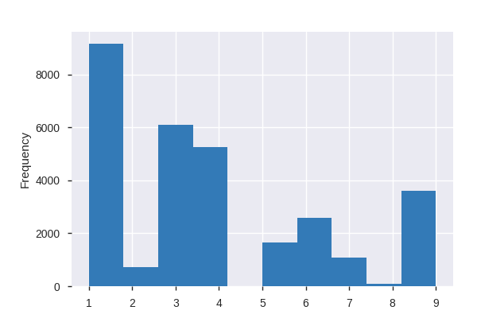

**Common Values**

| Value | Count | Frequency (%) |  |
| --- | --- | --- | --- |
| 1.0 | 9150 | 1.7% |  |
| 3.0 | 6102 | 1.1% |  |
| 4.0 | 5251 | 1.0% |  |
| 9.0 | 3613 | 0.7% |  |
| 6.0 | 2582 | 0.5% |  |
| 5.0 | 1661 | 0.3% |  |
| 7.0 | 1070 | 0.2% |  |
| 2.0 | 706 | 0.1% |  |
| 8.0 | 78 | 0.0% |  |
| (Missing) | 506868 | 94.4% |  |

**Extreme Values**

Minimum 5 values

| Value | Count | Frequency (%) |  |
| --- | --- | --- | --- |
| 1.0 | 9150 | 1.7% |  |
| 2.0 | 706 | 0.1% |  |
| 3.0 | 6102 | 1.1% |  |
| 4.0 | 5251 | 1.0% |  |
| 5.0 | 1661 | 0.3% |  |

Maximum 5 values

| Value | Count | Frequency (%) |  |
| --- | --- | --- | --- |
| 5.0 | 1661 | 0.3% |  |
| 6.0 | 2582 | 0.5% |  |
| 7.0 | 1070 | 0.2% |  |
| 8.0 | 78 | 0.0% |  |
| 9.0 | 3613 | 0.7% |  |

denial_reason-3  
Highly correlated

*This variable is highly correlated with `applicant_race-5` and should be ignored for analysis*

| Correlation | 1 |
| --- | --- |

denial_reason-4  
Highly correlated

*This variable is highly correlated with `applicant_race-3` and should be ignored for analysis*

| Correlation | 1 |
| --- | --- |

tract_population  
Numeric

| Distinct count | 3414 |
| --- | --- |
| Unique (%) | 0.6% |
| Missing (%) | 0.0% |
| Missing (n) | 0 |
| Infinite (%) | 0.0% |
| Infinite (n) | 0 |

| Mean | 4756.1 |
| --- | --- |
| Minimum | 0 |
| Maximum | 28926 |
| Zeros (%) | 0.7% |

Toggle details

**Statistics**

Quantile statistics

| Minimum | 0 |
| --- | --- |
| 5-th percentile | 2009 |
| Q1 | 3448 |
| Median | 4581 |
| Q3 | 5978 |
| 95-th percentile | 7949 |
| Maximum | 28926 |
| Range | 28926 |
| Interquartile range | 2530 |

Descriptive statistics

| Standard deviation | 1918.5 |
| --- | --- |
| Coef of variation | 0.40339 |
| Kurtosis | 4.2259 |
| Mean | 4756.1 |
| MAD | 1493.5 |
| Skewness | 0.85759 |
| Sum | 2554386186 |
| Variance | 3680800 |
| Memory size | 4.1 MiB |

**Histogram**

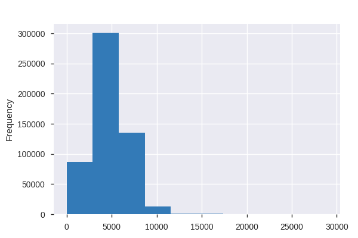

**Common Values**

| Value | Count | Frequency (%) |  |
| --- | --- | --- | --- |
| 0 | 3824 | 0.7% |  |
| 6991 | 972 | 0.2% |  |
| 3755 | 925 | 0.2% |  |
| 6295 | 777 | 0.1% |  |
| 6573 | 772 | 0.1% |  |
| 4686 | 717 | 0.1% |  |
| 4911 | 704 | 0.1% |  |
| 4388 | 697 | 0.1% |  |
| 3684 | 670 | 0.1% |  |
| 4312 | 670 | 0.1% |  |
| Other values (3404) | 526353 | 98.0% |  |

**Extreme Values**

Minimum 5 values

| Value | Count | Frequency (%) |  |
| --- | --- | --- | --- |
| 0 | 3824 | 0.7% |  |
| 5 | 12 | 0.0% |  |
| 8 | 2 | 0.0% |  |
| 18 | 4 | 0.0% |  |
| 20 | 20 | 0.0% |  |

Maximum 5 values

| Value | Count | Frequency (%) |  |
| --- | --- | --- | --- |
| 14693 | 294 | 0.1% |  |
| 15880 | 248 | 0.0% |  |
| 16200 | 2 | 0.0% |  |
| 16231 | 24 | 0.0% |  |
| 28926 | 63 | 0.0% |  |

tract_minority_population_percent  
Highly correlated

*This variable is highly correlated with `co-applicant_ethnicity-4` and should be ignored for analysis*

| Correlation | 1 |
| --- | --- |

ffiec_msa_md_median_family_income  
Numeric

| Distinct count | 52 |
| --- | --- |
| Unique (%) | 0.0% |
| Missing (%) | 0.0% |
| Missing (n) | 0 |
| Infinite (%) | 0.0% |
| Infinite (n) | 0 |

| Mean | 84760 |
| --- | --- |
| Minimum | 0 |
| Maximum | 123400 |
| Zeros (%) | 0.7% |

Toggle details

**Statistics**

Quantile statistics

| Minimum | 0 |
| --- | --- |
| 5-th percentile | 64300 |
| Q1 | 74700 |
| Median | 78000 |
| Q3 | 86400 |
| 95-th percentile | 116700 |
| Maximum | 123400 |
| Range | 123400 |
| Interquartile range | 11700 |

Descriptive statistics

| Standard deviation | 18961 |
| --- | --- |
| Coef of variation | 0.22371 |
| Kurtosis | 1.7356 |
| Mean | 84760 |
| MAD | 14781 |
| Skewness | 0.23245 |
| Sum | 45522762300 |
| Variance | 359540000 |
| Memory size | 4.1 MiB |

**Histogram**

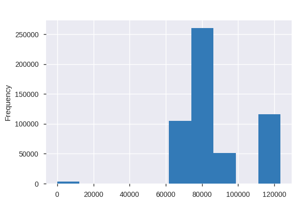

**Common Values**

| Value | Count | Frequency (%) |  |
| --- | --- | --- | --- |
| 78000 | 192503 | 35.8% |  |
| 116700 | 116444 | 21.7% |  |
| 74000 | 41054 | 7.6% |  |
| 74700 | 40210 | 7.5% |  |
| 64300 | 37368 | 7.0% |  |
| 86400 | 35078 | 6.5% |  |
| 74100 | 21451 | 4.0% |  |
| 97400 | 14589 | 2.7% |  |
| 65000 | 8753 | 1.6% |  |
| 66900 | 6946 | 1.3% |  |
| Other values (42) | 22685 | 4.2% |  |

**Extreme Values**

Minimum 5 values

| Value | Count | Frequency (%) |  |
| --- | --- | --- | --- |
| 0 | 3794 | 0.7% |  |
| 49400 | 1 | 0.0% |  |
| 52100 | 1 | 0.0% |  |
| 52200 | 1 | 0.0% |  |
| 53400 | 1 | 0.0% |  |

Maximum 5 values

| Value | Count | Frequency (%) |  |
| --- | --- | --- | --- |
| 107900 | 2 | 0.0% |  |
| 111200 | 8 | 0.0% |  |
| 114900 | 1 | 0.0% |  |
| 116700 | 116444 | 21.7% |  |
| 123400 | 1 | 0.0% |  |

tract_to_msa_income_percentage  
Highly correlated

*This variable is highly correlated with `co-applicant_ethnicity-4` and should be ignored for analysis*

| Correlation | 1 |
| --- | --- |

tract_owner_occupied_units  
Numeric

| Distinct count | 1842 |
| --- | --- |
| Unique (%) | 0.3% |
| Missing (%) | 0.0% |
| Missing (n) | 0 |
| Infinite (%) | 0.0% |
| Infinite (n) | 0 |

| Mean | 1189.8 |
| --- | --- |
| Minimum | 0 |
| Maximum | 4682 |
| Zeros (%) | 0.8% |

Toggle details

**Statistics**

Quantile statistics

| Minimum | 0 |
| --- | --- |
| 5-th percentile | 253 |
| Q1 | 716 |
| Median | 1175 |
| Q3 | 1611 |
| 95-th percentile | 2221 |
| Maximum | 4682 |
| Range | 4682 |
| Interquartile range | 895 |

Descriptive statistics

| Standard deviation | 612.54 |
| --- | --- |
| Coef of variation | 0.5148 |
| Kurtosis | -0.30206 |
| Mean | 1189.8 |
| MAD | 502.97 |
| Skewness | 0.27604 |
| Sum | 639044567 |
| Variance | 375200 |
| Memory size | 4.1 MiB |

**Histogram**

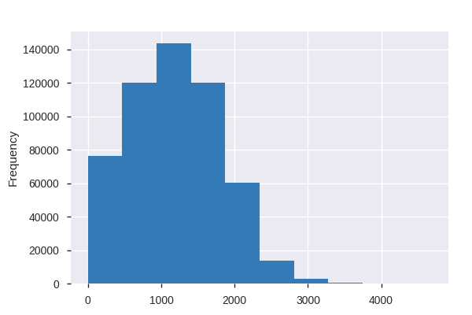

**Common Values**

| Value | Count | Frequency (%) |  |
| --- | --- | --- | --- |
| 0 | 4046 | 0.8% |  |
| 2013 | 1383 | 0.3% |  |
| 1390 | 1352 | 0.3% |  |
| 1445 | 1213 | 0.2% |  |
| 1594 | 1135 | 0.2% |  |
| 1122 | 1126 | 0.2% |  |
| 1049 | 1054 | 0.2% |  |
| 1943 | 1051 | 0.2% |  |
| 972 | 1044 | 0.2% |  |
| 1227 | 1038 | 0.2% |  |
| Other values (1832) | 522639 | 97.3% |  |

**Extreme Values**

Minimum 5 values

| Value | Count | Frequency (%) |  |
| --- | --- | --- | --- |
| 0 | 4046 | 0.8% |  |
| 2 | 3 | 0.0% |  |
| 4 | 16 | 0.0% |  |
| 5 | 29 | 0.0% |  |
| 6 | 35 | 0.0% |  |

Maximum 5 values

| Value | Count | Frequency (%) |  |
| --- | --- | --- | --- |
| 3218 | 389 | 0.1% |  |
| 3277 | 603 | 0.1% |  |
| 3348 | 1 | 0.0% |  |
| 3446 | 240 | 0.0% |  |
| 4682 | 63 | 0.0% |  |

tract_one_to_four_family_homes  
Numeric

| Distinct count | 2231 |
| --- | --- |
| Unique (%) | 0.4% |
| Missing (%) | 0.0% |
| Missing (n) | 0 |
| Infinite (%) | 0.0% |
| Infinite (n) | 0 |

| Mean | 1543.8 |
| --- | --- |
| Minimum | 0 |
| Maximum | 6541 |
| Zeros (%) | 0.8% |

Toggle details

**Statistics**

Quantile statistics

| Minimum | 0 |
| --- | --- |
| 5-th percentile | 230 |
| Q1 | 1008 |
| Median | 1541 |
| Q3 | 2039 |
| 95-th percentile | 2799 |
| Maximum | 6541 |
| Range | 6541 |
| Interquartile range | 1031 |

Descriptive statistics

| Standard deviation | 796.57 |
| --- | --- |
| Coef of variation | 0.51598 |
| Kurtosis | 2.1903 |
| Mean | 1543.8 |
| MAD | 620.25 |
| Skewness | 0.63218 |
| Sum | 829141476 |
| Variance | 634530 |
| Memory size | 4.1 MiB |

**Histogram**

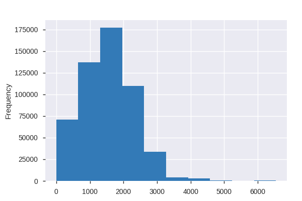

**Common Values**

| Value | Count | Frequency (%) |  |
| --- | --- | --- | --- |
| 0 | 4317 | 0.8% |  |
| 1593 | 1256 | 0.2% |  |
| 1782 | 1180 | 0.2% |  |
| 1808 | 1167 | 0.2% |  |
| 1986 | 1124 | 0.2% |  |
| 2116 | 1093 | 0.2% |  |
| 1570 | 1070 | 0.2% |  |
| 1673 | 1067 | 0.2% |  |
| 1929 | 1066 | 0.2% |  |
| 2230 | 1006 | 0.2% |  |
| Other values (2221) | 522735 | 97.3% |  |

**Extreme Values**

Minimum 5 values

| Value | Count | Frequency (%) |  |
| --- | --- | --- | --- |
| 0 | 4317 | 0.8% |  |
| 4 | 5 | 0.0% |  |
| 5 | 83 | 0.0% |  |
| 6 | 3 | 0.0% |  |
| 9 | 95 | 0.0% |  |

Maximum 5 values

| Value | Count | Frequency (%) |  |
| --- | --- | --- | --- |
| 4314 | 386 | 0.1% |  |
| 4750 | 558 | 0.1% |  |
| 4763 | 183 | 0.0% |  |
| 5321 | 273 | 0.1% |  |
| 6541 | 701 | 0.1% |  |

tract_median_age_of_housing_units  
Highly correlated

*This variable is highly correlated with `co-applicant_ethnicity-4` and should be ignored for analysis*

| Correlation | 1 |
| --- | --- |